# Feature Optimization for Coffee Adulteration Detection Using Hyperspectral Imaging and Artificial Neural Networks: RFE and GA with SNV+SG+1st Derivative

## Define the Fitness Function for GA

- This function evaluates subsets of features selected by GA using RFE with a Random Forest (RF) model.

```r
# Detect the number of cores
num_cores <- detectCores()
# Print the number of cores
print(paste("Number of cores available:", num_cores))
```

```
[1] "Number of cores available: 8"
```

```r
# Fitness Function
fitness_ga_rfe <- function(subset) {
  # Identify selected features based on the binary subset
  selected_features <- which(subset == 1)

  # Penalize empty subsets to avoid errors
  if (length(selected_features) == 0) return(Inf)

  # Subset the training feature matrix to selected features
  X_selected <- X_train[, selected_features]

  # Define control for rfe
  control <- rfeControl(functions = rfFuncs,  # Use Random Forest for rfe
                        method = "cv",       # Cross-validation
                        number = 10)         # 10-fold CV

  # Apply rfe to the selected subset of features
  rfe_result <- rfe(X_selected, y_train, rfeControl = control)

  # Return the negative accuracy as the fitness score (to maximize accuracy)
  return(-rfe_result$results$Accuracy[which.max(rfe_result$results$Accuracy)])
}
```

## Run the Genetic Algorithm

```r
# Set seed for reproducibility
set.seed(123)

num_features <- ncol(X_train) # Number of features
dataset_name <- "snv_sg_1d"   # Set the dataset name dynamically

# Define paths for the execution flag and GA result
flag_file <- paste0("ga_executed_flag_", dataset_name, ".RData")
result_file <- paste0("ga_result_", dataset_name, ".RData")

# Check if the result file exists
if (!file.exists(result_file)) {
  message("No result file found. Running the Genetic Algorithm (GA).")

  # Register cluster for caret to train the models in parallel
  cl <- makeCluster(6, type = "SOCK")
  suppressWarnings(suppressMessages(registerDoSNOW(cl)))

  # Register start time
  start_time <- Sys.time()

  # Run the Genetic Algorithm
  ga_result <- ga(
    type = "binary",
    fitness = fitness_ga_rfe,
    nBits = num_features,             # Number of features
    popSize = 20,                     # Population size
    maxiter = 50,                     # Maximum iterations
    run = 10,                         # Convergence stopping criterion
    names = colnames(train_data[, -ncol(train_data)]),  # Feature names
    pcrossover = 0.8,                 # Probability of crossover
    pmutation = 0.1,                  # Probability of mutation
    maxFitness = -0.9,                # Stop when fitness reaches target
    parallel = TRUE,                  # Enable parallel processing
    monitor = gaMonitor,              # Track progress
    seed = 123                        # Reproducibility
  )

  # Stop the cluster
  stopCluster(cl)

  # Register end time
  end_time <- Sys.time()
  print(paste('Time to run the GA model:', end_time - start_time))

  # Save the GA result and execution flag
  ga_executed <- TRUE
  save(ga_executed, ga_result, file = result_file)  # Save both flag and results

  message("GA execution completed and results saved.")

} else {
  # Load previously saved results
  message("Result file found. Loading saved GA results.")
  load(result_file)
  message(paste("GA already executed for dataset:", dataset_name))
}
```

```
Result file found. Loading saved GA results.
```

```
GA already executed for dataset: snv_sg_1d
```

## Visualization Plot

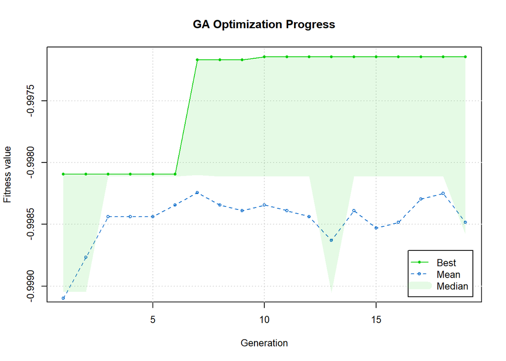

```r
par (cex = 0.8)
plot(ga_result, main = "GA Optimization Progress")
```

```r
par(cex = 1)
```

## Analyze GA results

```r
summary(ga_result)
```

```
── Genetic Algorithm ───────────────────

GA settings:
Type                  =  binary
Population size       =  20
Number of generations =  50
Elitism               =  1
Crossover probability =  0.8
Mutation probability  =  0.1

GA results:
Iterations             = 19
Fitness function value = -0.9971429
Solution =
     X935.609985 X939.059998 X942.52002 X945.97998 X949.429993 X952.890015
[1,]           1           0          1          1           1           0
     X956.349976 X959.809998 X963.27002 X966.72998  ...  X1716.650024
[1,]           0           0          1          0                  0
     X1720.22998
[1,]           0
```

## Post-Selection

```r
# Get the best feature subset
best_features <- which(ga_result@solution == 1)
selected_feature_names <- colnames(train_data)[best_features]
print(selected_feature_names)
```

```
  [1] "X935.609985"  "X942.52002"   "X945.97998"   "X949.429993"  "X963.27002"
  [6] "X970.190002"  "X973.650024"  "X1011.77002"  "X1015.23999"  "X1018.710022"
 [11] "X1025.650024" "X1029.119995" "X1032.589966" "X1036.060059" "X1039.530029"
 [16] "X1056.900024" "X1088.199951" "X1091.680054" "X1123.040039" "X1126.52002"
 [21] "X1130.01001"  "X1136.98999"  "X1150.939941" "X1154.430054" "X1164.910034"
 [26] "X1168.400024" "X1171.900024" "X1175.390015" "X1178.890015" "X1203.369995"
 [31] "X1217.369995" "X1224.369995" "X1227.869995" "X1231.380005" "X1234.880005"
 [36] "X1245.400024" "X1248.900024" "X1255.920044" "X1259.420044" "X1266.439941"
 [41] "X1269.949951" "X1273.459961" "X1276.969971" "X1283.98999"  "X1298.050049"
 [46] "X1301.560059" "X1305.079956" "X1308.589966" "X1312.109985" "X1315.619995"
 [51] "X1326.180054" "X1333.219971" "X1343.780029" "X1347.300049" "X1350.819946"
 [56] "X1354.349976" "X1364.920044" "X1368.439941" "X1375.5"      "X1382.550049"
 [61] "X1396.670044" "X1400.199951" "X1403.72998"  "X1421.390015" "X1431.98999"
 [66] "X1442.599976" "X1446.140015" "X1460.300049" "X1463.839966" "X1467.380005"
 [71] "X1474.459961" "X1481.550049" "X1485.089966" "X1492.180054" "X1495.72998"
 [76] "X1499.27002"  "X1509.910034" "X1513.459961" "X1517.01001"  "X1531.209961"
 [81] "X1541.869995" "X1548.97998"  "X1552.530029" "X1556.089966" "X1559.640015"
 [86] "X1563.199951" "X1570.310059" "X1580.98999"  "X1591.670044" "X1602.349976"
 [91] "X1605.920044" "X1609.47998"  "X1616.609985" "X1620.170044" "X1627.310059"
 [96] "X1638.01001"  "X1641.579956" "X1645.150024" "X1652.290039" "X1655.859985"
[101] "X1659.430054" "X1666.569946" "X1670.140015" "X1673.719971" "X1677.290039"
[106] "X1691.589966" "X1695.170044" "X1698.75"     "X1702.329956" "X1713.069946"
```

```r
print(paste('The number of selected variables are', length(selected_feature_names)))
```

```
[1] "The number of selected variables are 110"
```

```r
n_selected <- as.numeric(length(selected_feature_names))
```

## Create a Data frame with the Selected Features

```r
# Subset the training and test data using the selected features
X_train_selected <- X_train[, selected_feature_names, drop = FALSE]
X_test_selected <- X_test[, selected_feature_names, drop = FALSE]

# Keep y_train and y_test as-is
y_train_selected <- y_train
y_test_selected <- y_test


#Merge data_frame
train_merged <- cbind(X_train_selected, binary_class = y_train_selected)
test_merged <- cbind(X_test_selected, binary_class = y_test_selected)

dim(train_merged)
```

```
[1] 1055  111
```

```r
dim(test_merged)
```

```
[1] 414 111
```

```r
table(train_merged$binary_class)
```

```
 adulterated pure_arabica
        1007           48
```

```r
table(test_merged$binary_class)
```

```
 adulterated pure_arabica
         387           27
```

## Create a Data frame with the Selected Features for SMOTE Data

```r
X_train_selected_smote <- X_train_smote[,selected_feature_names, drop = FALSE]
X_test_selected_smote <- X_test[, selected_feature_names, drop = FALSE]

# Keep y_train and y_test as-is
y_train_selected_smote <- y_train
y_test_selected_smote <- y_test

#Merge data_frame
train_merged_smote <- cbind(X_train_selected_smote, binary_class = smote_data$binary_class)
test_merged_smote <- cbind(X_test_selected_smote, binary_class = y_test_selected_smote)

dim(train_merged_smote)
```

```
[1] 1872  111
```

```r
dim(test_merged_smote)
```

```
[1] 414 111
```

```r
table(train_merged_smote$binary_class)
```

```
 adulterated pure_arabica
         912          960
```

```r
table(test_merged_smote$binary_class)
```

```
 adulterated pure_arabica
         387           27
```

## Check correlations by HeatMaps

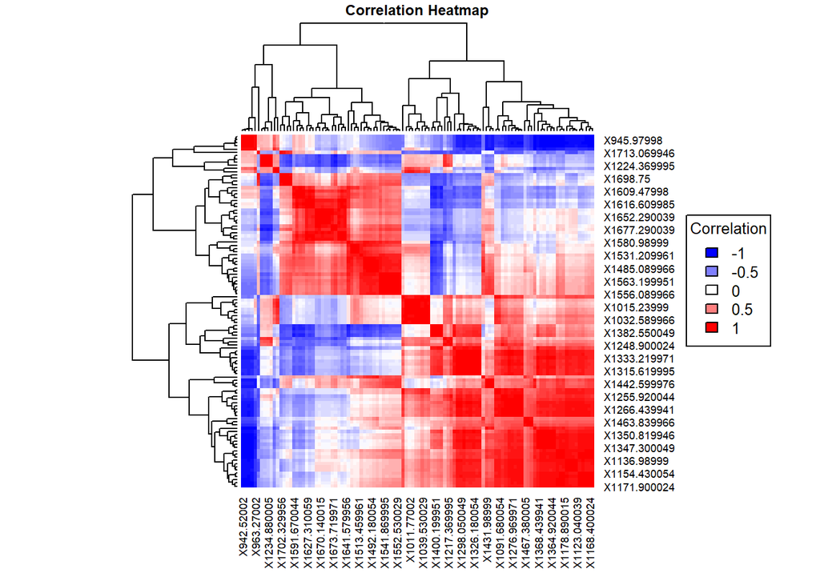

```r
# Calculate the correlation matrix

#Imbalanced Data

#Calculate correlations
corr <- cor(train_merged[, -(n_selected+1)])

# Create a heat map
par(cex.main = 0.6)
heatmap(corr, symm = TRUE,
        col = colorRampPalette(c("blue", "white", "red"))(50),
        main = "Correlation Heatmap")

# Add legend

legend("right",
       legend = seq(-1, 1, by = 0.5),  # Correlation range
       fill = colorRampPalette(c("blue", "white", "red"))(5),
       title = "Correlation", cex = 0.8)
```

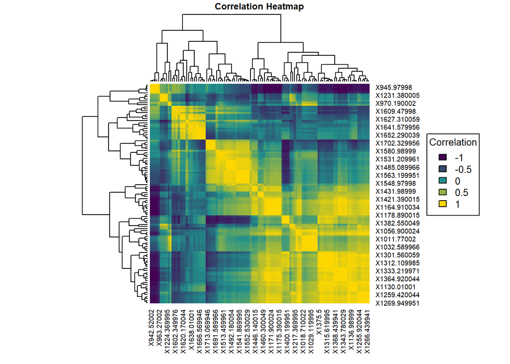

```r
# SMOTE Data
par(cex.main = 0.6)
corr <- cor(train_merged_smote[, -(n_selected+1)])
# Create heat map
heatmap(corr, symm = TRUE,
        col = colorRampPalette(c("#440154", "#21908C", "gold"))(50),
        main = 'Correlation Heatmap',cex.main = 0.6)

# Add legend
legend("right",
       legend = seq(-1, 1, by = 0.5),  # Correlation range
       fill = colorRampPalette(c("#440154", "#21908C", "gold"))(5),
       title = "Correlation",
       cex = 0.8)
```

- The correlation heat maps reveal that some variables remain highly correlated. To address this issue and mitigate multicollinearity, we will employ Principal Component Analysis (PCA). We will then proceed to train our models with features generated by PCA. This aims to speed up processing time.

## PreProcess by PCA, Centering and Scaling Data

```r
# Imbalanced Data
pca_Preprocess <- preProcess(train_merged, method = c("center", "scale", "pca"))
train_mergedPreprocessed <- predict(pca_Preprocess, train_merged) # train data
test_mergedPreprocessed <- predict(pca_Preprocess,test_merged) # apply on test data

# SMOTE Data
pca_Preprocess_smote <- preProcess(train_merged_smote,method = c("center", "scale", "pca"))
train_merged_smote_Preprocessed <- predict(pca_Preprocess_smote,train_merged_smote)
test_merged_smote_Preprocessed <- predict(pca_Preprocess_smote,test_merged_smote)

# Check dimensions of the preprocessed data to ensure consistency

dim(train_mergedPreprocessed)
```

```
[1] 1055    6
```

```r
dim(test_mergedPreprocessed)
```

```
[1] 414   6
```

```r
dim(train_merged_smote_Preprocessed)
```

```
[1] 1872    6
```

```r
dim(test_merged_smote_Preprocessed)
```

```
[1] 414   6
```

## Set Up Training Parameters

```r
# Set random seed for reproducibility

set.seed (123)

# Set up the training control(10 folds 10 times cross_validation)
control <- trainControl(method = "repeatedcv", number = 10, repeats = 10,
                        classProbs = TRUE, savePredictions = "final",
                        summaryFunction = multiClassSummary,
                        selectionFunction = 'oneSE', allowParallel = TRUE)

# One SE rule will be used to select simplest yet optimal model within the 'best model'
```

```r
#Set the metric as accuracy
metric<-"Accuracy"
```

```r
# Detect the number of cores
num_cores <- detectCores()
# Print the number of cores
print(paste("Number of cores available:", num_cores))
```

```
[1] "Number of cores available: 8"
```

```r
# Hyperparameter Tuning
# Set tune grid to find optimal value of size and decay on cross-validation
# Size is the number of number of units (neurons) in the hidden layer of the neural network
# Decay is the regularization parameter; adds penalty to the loss function

grid <- expand.grid(.size=seq(1,10, by =1),.decay=c(0,0.001,0.01,0.1,0.2,0.3,0.4,0.5))
```

## Train the Models

```r
#Register cluster for caret to train the models in parallel
set.seed(123)
cl<-makeCluster(6,type = "SOCK")
suppressWarnings(suppressMessages(
  registerDoSNOW(cl)))

# Start_time
start_time<-Sys.time()

#Train the model using cross-validation (10 folds, 10 times)
fit_nnet_snv_sg_1d<-train(binary_class ~., data = train_mergedPreprocessed,
                      method = 'nnet', tuneGrid = grid,
                      trControl = control, metric = 'Accuracy',
                      trace = FALSE, MaxNWts = 1000, maxit = 300) #unmodified data
#End_time
end_time<-Sys.time()
model_training_time<-end_time-start_time
stopCluster(cl) # Stop the parallel run cluster

print(model_training_time)
```

```
Time difference of 8.825234 mins
```

```r
print(fit_nnet_snv_sg_1d) # Model on imbalanced data
```

```
Neural Network

1055 samples
   5 predictor
   2 classes: 'adulterated', 'pure_arabica'

No pre-processing
Resampling: Cross-Validated (10 fold, repeated 10 times)
Summary of sample sizes: 949, 949, 949, 950, 949, 950, ...
Resampling results across tuning parameters:

  size  decay  logLoss      AUC        prAUC       Accuracy   Kappa
   1    0.000  0.022574054  0.9944010  0.14788975  0.9947996  0.9426594
   1    0.001  0.004606930  0.9998465  0.66905764  0.9986748  0.9842209
   1    0.010  0.003378799  0.9999802  0.79311519  0.9990530  0.9883046
   1    0.100  0.009456622  0.9999800  0.88985082  0.9991473  0.9892439
   1    0.200  0.014717902  0.9999008  0.88917268  0.9979155  0.9737704
   1    0.300  0.019267598  0.9998808  0.88898885  0.9979155  0.9737704
   1    0.400  0.023251734  0.9998610  0.88880502  0.9978203  0.9723380
   1    0.500  0.026850540  0.9998412  0.88862120  0.9977251  0.9703946
   2    0.000  0.045819609  0.9889792  0.13087494  0.9928922  0.9275087
   2    0.001  0.014311755  0.9960891  0.54673159  0.9960252  0.9591443
   2    0.010  0.008784981  0.9989179  0.86598512  0.9981060  0.9796000
   2    0.100  0.007219611  1.0000000  0.89003465  0.9999057  0.9990416
   2    0.200  0.011242476  1.0000000  0.89003465  0.9991482  0.9889278
   2    0.300  0.014536933  1.0000000  0.89003465  0.9988625  0.9848140
   2    0.400  0.017690898  1.0000000  0.89003465  0.9982947  0.9778546
   2    0.500  0.020421335  1.0000000  0.89003465  0.9981060  0.9755351
   3    0.000  0.045474661  0.9920748  0.12984261  0.9950782  0.9464808
   3    0.001  0.006047337  0.9998206  0.64659122  0.9982938  0.9800500
   3    0.010  0.004562493  0.9999604  0.88579593  0.9988607  0.9861654
   3    0.100  0.007269767  1.0000000  0.89003465  0.9989578  0.9868087
   3    0.200  0.010806688  1.0000000  0.89003465  0.9990512  0.9874500
   3    0.300  0.014512698  1.0000000  0.89003465  0.9986739  0.9824945
   3    0.400  0.016655414  1.0000000  0.89003465  0.9986739  0.9828111
   3    0.500  0.019115776  1.0000000  0.89003465  0.9985786  0.9816508
   4    0.000  0.059933043  0.9888765  0.09421955  0.9945058  0.9405343
   4    0.001  0.004950730  0.9999406  0.62015171  0.9978203  0.9735981
   4    0.010  0.004604619  0.9999802  0.81983301  0.9982938  0.9798104
   4    0.100  0.006975817  1.0000000  0.89003465  0.9985795  0.9831758
```

[output cut: 202 more lines]

```
  0.9990186  0.9997030  0.9542323       0.9891015
  0.9990186  0.9999000  0.9544201       0.9892000
  0.9991167  1.0000000  0.9545153       0.9905000
  0.9990186  1.0000000  0.9545153       0.9892500
  0.9977334  0.9977139  0.9523347       0.9751069
  0.9985275  0.9991059  0.9536617       0.9840530
  0.9987235  0.9991059  0.9536617       0.9858030
  0.9991167  0.9992050  0.9537561       0.9901025
  0.9990186  0.9993040  0.9538504       0.9889020
  0.9990186  1.0000000  0.9545153       0.9892500
  0.9990186  1.0000000  0.9545153       0.9892500
  0.9990186  1.0000000  0.9545153       0.9892500

Accuracy was used to select the optimal model using  the one SE rule.
The final values used for the model were size = 2 and decay = 0.1.
```

```r
#Register cluster for caret to train the models in parallel
set.seed(123)
cl<-makeCluster(6,type = "SOCK")
suppressWarnings(suppressMessages(
  registerDoSNOW(cl)))

fit_nnet_smote_snv_sg_1d<-train(binary_class~., data = train_merged_smote_Preprocessed,
                            method ='nnet', tuneGrid = grid,
                            trControl = control, metric = 'Accuracy',
                            trace = FALSE, MaxNWts = 1000, maxit = 300)# SMOTE data
#End_time
end_time<-Sys.time()
model_training_time<-end_time-start_time
stopCluster(cl) # Stop the parallel run cluster

print(model_training_time)
```

```
Time difference of 22.30495 mins
```

```r
print(fit_nnet_smote_snv_sg_1d)
```

```
Neural Network

1872 samples
   5 predictor
   2 classes: 'adulterated', 'pure_arabica'

No pre-processing
Resampling: Cross-Validated (10 fold, repeated 10 times)
Summary of sample sizes: 1684, 1685, 1685, 1685, 1685, 1685, ...
Resampling results across tuning parameters:

  size  decay  logLoss       AUC        prAUC       Accuracy   Kappa
   1    0.000  0.0313609529  0.9956734  0.01857816  0.9952441  0.9904758
   1    0.001  0.0188600057  0.9983028  0.30207433  0.9969004  0.9937936
   1    0.010  0.0105412459  0.9988850  0.60546565  0.9977560  0.9955070
   1    0.100  0.0117804511  0.9985956  0.76585370  0.9982896  0.9965742
   1    0.200  0.0105463680  0.9997917  0.82404991  0.9986108  0.9972188
   1    0.300  0.0136289889  0.9998168  0.85168507  0.9981298  0.9962557
   1    0.400  0.0167771181  0.9994128  0.86818526  0.9979159  0.9958265
   1    0.500  0.0177810336  0.9999405  0.88097474  0.9982902  0.9965769
   2    0.000  0.0108926786  0.9989976  0.04713934  0.9986108  0.9972185
   2    0.001  0.0030123484  0.9999989  0.87115768  0.9993589  0.9987164
   2    0.010  0.0027014908  0.9999966  0.91836622  0.9994120  0.9988229
   2    0.100  0.0046424299  0.9999966  0.96431047  0.9994120  0.9988229
   2    0.200  0.0069828574  0.9999966  0.97745905  0.9990912  0.9981805
   2    0.300  0.0086658908  0.9999920  0.98227420  0.9989848  0.9979674
   2    0.400  0.0106770316  0.9999954  0.98398085  0.9985576  0.9971120
   2    0.500  0.0121273151  0.9999886  0.98568217  0.9982376  0.9964714
   3    0.000  0.0021091038  0.9999771  0.03657736  0.9996794  0.9993582
   3    0.001  0.0022453213  1.0000000  0.66012290  0.9994120  0.9988229
   3    0.010  0.0021756092  1.0000000  0.96289547  0.9994120  0.9988229
   3    0.100  0.0038799253  0.9999977  0.98502888  0.9994120  0.9988229
   3    0.200  0.0052395572  1.0000000  0.98843178  0.9991450  0.9982882
   3    0.300  0.0068322213  1.0000000  0.98859542  0.9986637  0.9973243
   3    0.400  0.0079255706  1.0000000  0.98875966  0.9985573  0.9971116
   3    0.500  0.0096361453  1.0000000  0.98897944  0.9978624  0.9957192
   4    0.000  0.0074150037  0.9998034  0.02997803  0.9995193  0.9990377
   4    0.001  0.0023256726  1.0000000  0.62167441  0.9994120  0.9988229
   4    0.010  0.0016467371  1.0000000  0.95509386  0.9995187  0.9990364
   4    0.100  0.0033372736  0.9999989  0.98853933  0.9994120  0.9988229
```

[output cut: 202 more lines]

```
  0.9991837  0.9984651  0.4864293       0.9988159
  1.0000000  0.9984627  0.4864288       0.9992314
  1.0000000  0.9981331  0.4862683       0.9990665
  1.0000000  0.9972563  0.4858411       0.9986282
  1.0000000  0.9987948  0.4865898       0.9993974
  1.0000000  0.9993419  0.4868566       0.9996709
  1.0000000  0.9990122  0.4866962       0.9995061
  1.0000000  0.9987924  0.4865892       0.9993962
  1.0000000  0.9987924  0.4865892       0.9993962
  1.0000000  0.9984627  0.4864288       0.9992314
  1.0000000  0.9981331  0.4862683       0.9990665
  1.0000000  0.9976947  0.4860547       0.9988473

Accuracy was used to select the optimal model using  the one SE rule.
The final values used for the model were size = 7 and decay = 0.
```

## Save the models for future use

```r
saveRDS(fit_nnet_snv_sg_1d, "fit_nnet_snv_sg_1d.rds")
saveRDS(fit_nnet_smote_snv_sg_1d, "fit_nnet_smote_snv_sg_1d.rds")
```

## Display the cross-validation results

```r
print(paste('The optimal parametrers for training the nnet model are', round(as.numeric(fit_nnet_snv_sg_1d$bestTune$size),2),'neurons','and decay value of',fit_nnet_snv_sg_1d$bestTune$decay)) # unmodified data
```

```
[1] "The optimal parametrers for training the nnet model are 2 neurons and decay value of 0.1"
```

```r
print(paste('The optimal parametrers for training the nnet model are', round(as.numeric(fit_nnet_smote_snv_sg_1d$bestTune$size),2),'neurons','and decay value of',fit_nnet_smote_snv_sg_1d$bestTune$decay)) # SMOTE data
```

```
[1] "The optimal parametrers for training the nnet model are 7 neurons and decay value of 0"
```

```r
# Imbalanced data
kable(fit_nnet_snv_sg_1d$results,
      caption = "Cross-Validation Results on Imbalanced Data")
```

Cross-Validation Results on Imbalanced Data

| size | decay | logLoss | AUC | prAUC | Accuracy | Kappa | F1 | Sensitivity | Specificity | Pos_Pred_Value | Neg_Pred_Value | Precision | Recall | Detection_Rate | Balanced_Accuracy | logLossSD | AUCSD | prAUCSD | AccuracySD | KappaSD | F1SD | SensitivitySD | SpecificitySD | Pos_Pred_ValueSD | Neg_Pred_ValueSD | PrecisionSD | RecallSD | Detection_RateSD | Balanced_AccuracySD |
| --- | --- | --- | --- | --- | --- | --- | --- | --- | --- | --- | --- | --- | --- | --- | --- | --- | --- | --- | --- | --- | --- | --- | --- | --- | --- | --- | --- | --- | --- |
| 1 | 0.000 | 0.0225741 | 0.9944010 | 0.1478897 | 0.9947996 | 0.9426594 | 0.9972603 | 0.9955376 | 0.9800 | 0.9990352 | 0.9295414 | 0.9990352 | 0.9955376 | 0.9502592 | 0.9877688 | 0.0545202 | 0.0239096 | 0.1566282 | 0.0087384 | 0.1194793 | 0.0045949 | 0.0077660 | 0.1082459 | 0.0051426 | 0.1107279 | 0.0051426 | 0.0077660 | 0.0086343 | 0.0540305 |
| 1 | 0.001 | 0.0046069 | 0.9998465 | 0.6690576 | 0.9986748 | 0.9842209 | 0.9993064 | 0.9996040 | 0.9795 | 0.9990157 | 0.9931429 | 0.9990157 | 0.9996040 | 0.9541371 | 0.9895520 | 0.0100370 | 0.0009220 | 0.0384583 | 0.0038071 | 0.0441726 | 0.0019963 | 0.0024047 | 0.0619934 | 0.0029677 | 0.0398140 | 0.0029677 | 0.0024047 | 0.0042697 | 0.0311150 |
| 1 | 0.010 | 0.0033788 | 0.9999802 | 0.7931152 | 0.9990530 | 0.9883046 | 0.9995054 | 0.9999010 | 0.9815 | 0.9991138 | 0.9980000 | 0.9991138 | 0.9999010 | 0.9544210 | 0.9907005 | 0.0040358 | 0.0001980 | 0.0304761 | 0.0031545 | 0.0384514 | 0.0016489 | 0.0009901 | 0.0593121 | 0.0028323 | 0.0200000 | 0.0028323 | 0.0009901 | 0.0038253 | 0.0298128 |
| 1 | 0.100 | 0.0094566 | 0.9999800 | 0.8898508 | 0.9991473 | 0.9892439 | 0.9995552 | 1.0000000 | 0.9815 | 0.9991147 | 1.0000000 | 0.9991147 | 1.0000000 | 0.9545153 | 0.9907500 | 0.0043712 | 0.0002000 | 0.0101265 | 0.0027249 | 0.0345055 | 0.0014216 | 0.0000000 | 0.0593121 | 0.0028292 | 0.0000000 | 0.0028292 | 0.0000000 | 0.0036636 | 0.0296561 |
| 1 | 0.200 | 0.0147179 | 0.9999008 | 0.8891727 | 0.9979155 | 0.9737704 | 0.9989118 | 0.9998000 | 0.9580 | 0.9980353 | 0.9971429 | 0.9980353 | 0.9998000 | 0.9543248 | 0.9789000 | 0.0051682 | 0.0005178 | 0.0105605 | 0.0041705 | 0.0517202 | 0.0021809 | 0.0020000 | 0.0849004 | 0.0039492 | 0.0285714 | 0.0039492 | 0.0020000 | 0.0042274 | 0.0424120 |
| 1 | 0.300 | 0.0192676 | 0.9998808 | 0.8889888 | 0.9979155 | 0.9737704 | 0.9989118 | 0.9998000 | 0.9580 | 0.9980353 | 0.9971429 | 0.9980353 | 0.9998000 | 0.9543248 | 0.9789000 | 0.0055059 | 0.0005515 | 0.0106179 | 0.0041705 | 0.0517202 | 0.0021809 | 0.0020000 | 0.0849004 | 0.0039492 | 0.0285714 | 0.0039492 | 0.0020000 | 0.0042274 | 0.0424120 |
| 1 | 0.400 | 0.0232517 | 0.9998610 | 0.8888050 | 0.9978203 | 0.9723380 | 0.9988625 | 0.9998000 | 0.9560 | 0.9979383 | 0.9971429 | 0.9979383 | 0.9998000 | 0.9543248 | 0.9779000 | 0.0056612 | 0.0005818 | 0.0106709 | 0.0044420 | 0.0560355 | 0.0023207 | 0.0020000 | 0.0908100 | 0.0042538 | 0.0285714 | 0.0042538 | 0.0020000 | 0.0042274 | 0.0453671 |
| 1 | 0.500 | 0.0268505 | 0.9998412 | 0.8886212 | 0.9977251 | 0.9703946 | 0.9988138 | 0.9998000 | 0.9535 | 0.9978421 | 0.9971429 | 0.9978421 | 0.9998000 | 0.9543248 | 0.9766500 | 0.0057174 | 0.0006101 | 0.0107204 | 0.0046959 | 0.0631574 | 0.0024489 | 0.0020000 | 0.0995584 | 0.0045302 | 0.0285714 | 0.0045302 | 0.0020000 | 0.0042274 | 0.0497420 |
| 2 | 0.000 | 0.0458196 | 0.9889792 | 0.1308749 | 0.9928922 | 0.9275087 | 0.9962480 | 0.9937455 | 0.9750 | 0.9988167 | 0.9044365 | 0.9988167 | 0.9937455 | 0.9485458 | 0.9843728 | 0.0889902 | 0.0283352 | 0.1386965 | 0.0087730 | 0.0832334 | 0.0046536 | 0.0092194 | 0.0683500 | 0.0032206 | 0.1288219 | 0.0032206 | 0.0092194 | 0.0095756 | 0.0336201 |
| 2 | 0.001 | 0.0143118 | 0.9960891 | 0.5467316 | 0.9960252 | 0.9591443 | 0.9979029 | 0.9965287 | 0.9855 | 0.9993079 | 0.9446310 | 0.9993079 | 0.9965287 | 0.9512035 | 0.9910144 | 0.0248292 | 0.0108638 | 0.1516058 | 0.0073852 | 0.0735956 | 0.0039067 | 0.0071000 | 0.0533215 | 0.0025355 | 0.1048417 | 0.0025355 | 0.0071000 | 0.0078931 | 0.0272136 |
| 2 | 0.010 | 0.0087850 | 0.9989179 | 0.8659851 | 0.9981060 | 0.9796000 | 0.9990039 | 0.9988079 | 0.9840 | 0.9992069 | 0.9792857 | 0.9992069 | 0.9988079 | 0.9533787 | 0.9914040 | 0.0191037 | 0.0037250 | 0.0715523 | 0.0055448 | 0.0588276 | 0.0029188 | 0.0040630 | 0.0545320 | 0.0027031 | 0.0681091 | 0.0027031 | 0.0040630 | 0.0055549 | 0.0282495 |
| 2 | 0.100 | 0.0072196 | 1.0000000 | 0.8900347 | 0.9999057 | 0.9990416 | 0.9999502 | 0.9999010 | 1.0000 | 1.0000000 | 0.9983333 | 1.0000000 | 0.9999010 | 0.9544210 | 0.9999505 | 0.0032567 | 0.0000000 | 0.0100504 | 0.0009434 | 0.0095841 | 0.0004975 | 0.0009901 | 0.0000000 | 0.0000000 | 0.0166667 | 0.0000000 | 0.0009901 | 0.0038253 | 0.0004950 |
| 2 | 0.200 | 0.0112425 | 1.0000000 | 0.8900347 | 0.9991482 | 0.9889278 | 0.9995562 | 1.0000000 | 0.9810 | 0.9991167 | 1.0000000 | 0.9991167 | 1.0000000 | 0.9545153 | 0.9905000 | 0.0037403 | 0.0000000 | 0.0100504 | 0.0027221 | 0.0356072 | 0.0014184 | 0.0000000 | 0.0610431 | 0.0028230 | 0.0000000 | 0.0028230 | 0.0000000 | 0.0036636 | 0.0305216 |
| 2 | 0.300 | 0.0145369 | 1.0000000 | 0.8900347 | 0.9988625 | 0.9848140 | 0.9994079 | 1.0000000 | 0.9740 | 0.9988216 | 1.0000000 | 0.9988216 | 1.0000000 | 0.9545153 | 0.9870000 | 0.0041292 | 0.0000000 | 0.0100504 | 0.0030958 | 0.0416572 | 0.0016115 | 0.0000000 | 0.0712373 | 0.0032073 | 0.0000000 | 0.0032073 | 0.0000000 | 0.0036636 | 0.0356186 |
| 2 | 0.400 | 0.0176909 | 1.0000000 | 0.8900347 | 0.9982947 | 0.9778546 | 0.9991113 | 1.0000000 | 0.9620 | 0.9982314 | 1.0000000 | 0.9982314 | 1.0000000 | 0.9545153 | 0.9810000 | 0.0043553 | 0.0000000 | 0.0100504 | 0.0036581 | 0.0478358 | 0.0019063 | 0.0000000 | 0.0819953 | 0.0037939 | 0.0000000 | 0.0037939 | 0.0000000 | 0.0036636 | 0.0409977 |
| 2 | 0.500 | 0.0204213 | 1.0000000 | 0.8900347 | 0.9981060 | 0.9755351 | 0.9990128 | 1.0000000 | 0.9580 | 0.9980353 | 1.0000000 | 0.9980353 | 1.0000000 | 0.9545153 | 0.9790000 | 0.0046475 | 0.0000000 | 0.0100504 | 0.0038071 | 0.0495053 | 0.0019843 | 0.0000000 | 0.0849004 | 0.0039492 | 0.0000000 | 0.0039492 | 0.0000000 | 0.0036636 | 0.0424502 |
| 3 | 0.000 | 0.0454747 | 0.9920748 | 0.1298426 | 0.9950782 | 0.9464808 | 0.9974102 | 0.9968257 | 0.9585 | 0.9980372 | 0.9520476 | 0.9980372 | 0.9968257 | 0.9514857 | 0.9776629 | 0.0880801 | 0.0255516 | 0.1279866 | 0.0075537 | 0.0777194 | 0.0039917 | 0.0074414 | 0.0884933 | 0.0041797 | 0.1049169 | 0.0041797 | 0.0074414 | 0.0080201 | 0.0437902 |
| 3 | 0.001 | 0.0060473 | 0.9998206 | 0.6465912 | 0.9982938 | 0.9800500 | 0.9991064 | 0.9992059 | 0.9795 | 0.9990138 | 0.9853333 | 0.9990138 | 0.9992059 | 0.9537570 | 0.9893530 | 0.0150338 | 0.0012728 | 0.0693352 | 0.0041263 | 0.0479924 | 0.0021621 | 0.0027064 | 0.0619934 | 0.0029737 | 0.0502117 | 0.0029737 | 0.0027064 | 0.0044005 | 0.0312171 |
| 3 | 0.010 | 0.0045625 | 0.9999604 | 0.8857959 | 0.9988607 | 0.9861654 | 0.9994044 | 0.9996030 | 0.9835 | 0.9992118 | 0.9926667 | 0.9992118 | 0.9996030 | 0.9541352 | 0.9915515 | 0.0074249 | 0.0003960 | 0.0321998 | 0.0031008 | 0.0378952 | 0.0016209 | 0.0019549 | 0.0564322 | 0.0026864 | 0.0362619 | 0.0026864 | 0.0019549 | 0.0038445 | 0.0281744 |
| 3 | 0.100 | 0.0072698 | 1.0000000 | 0.8900347 | 0.9989578 | 0.9868087 | 0.9994562 | 0.9998020 | 0.9810 | 0.9991157 | 0.9963333 | 0.9991157 | 0.9998020 | 0.9543257 | 0.9904010 | 0.0035627 | 0.0000000 | 0.0100504 | 0.0029795 | 0.0380106 | 0.0015547 | 0.0013931 | 0.0610431 | 0.0028261 | 0.0259045 | 0.0028261 | 0.0013931 | 0.0037550 | 0.0304984 |
| 3 | 0.200 | 0.0108067 | 1.0000000 | 0.8900347 | 0.9990512 | 0.9874500 | 0.9995059 | 0.9998010 | 0.9825 | 0.9992157 | 0.9960000 | 0.9992157 | 0.9998010 | 0.9543239 | 0.9911505 | 0.0040201 | 0.0000000 | 0.0100504 | 0.0028608 | 0.0381200 | 0.0014898 | 0.0014001 | 0.0600400 | 0.0026731 | 0.0281411 | 0.0026731 | 0.0014001 | 0.0035283 | 0.0299988 |
| 3 | 0.300 | 0.0145127 | 1.0000000 | 0.8900347 | 0.9986739 | 0.9824945 | 0.9993094 | 1.0000000 | 0.9700 | 0.9986255 | 1.0000000 | 0.9986255 | 1.0000000 | 0.9545153 | 0.9850000 | 0.0043121 | 0.0000000 | 0.0100504 | 0.0033034 | 0.0439368 | 0.0017204 | 0.0000000 | 0.0752101 | 0.0034238 | 0.0000000 | 0.0034238 | 0.0000000 | 0.0036636 | 0.0376051 |
| 3 | 0.400 | 0.0166554 | 1.0000000 | 0.8900347 | 0.9986739 | 0.9828111 | 0.9993089 | 1.0000000 | 0.9705 | 0.9986245 | 1.0000000 | 0.9986245 | 1.0000000 | 0.9545153 | 0.9852500 | 0.0046105 | 0.0000000 | 0.0100504 | 0.0033034 | 0.0430954 | 0.0017216 | 0.0000000 | 0.0738874 | 0.0034263 | 0.0000000 | 0.0034263 | 0.0000000 | 0.0036636 | 0.0369437 |
| 3 | 0.500 | 0.0191158 | 1.0000000 | 0.8900347 | 0.9985786 | 0.9816508 | 0.9992591 | 1.0000000 | 0.9685 | 0.9985255 | 1.0000000 | 0.9985255 | 1.0000000 | 0.9545153 | 0.9842500 | 0.0050073 | 0.0000000 | 0.0100504 | 0.0034007 | 0.0441762 | 0.0017725 | 0.0000000 | 0.0757638 | 0.0035277 | 0.0000000 | 0.0035277 | 0.0000000 | 0.0036636 | 0.0378819 |
| 4 | 0.000 | 0.0599330 | 0.9888765 | 0.0942195 | 0.9945058 | 0.9405343 | 0.9971078 | 0.9959317 | 0.9635 | 0.9983295 | 0.9365437 | 0.9983295 | 0.9959317 | 0.9506330 | 0.9797158 | 0.1307968 | 0.0353554 | 0.1004999 | 0.0077511 | 0.0788150 | 0.0041003 | 0.0077295 | 0.0864143 | 0.0039678 | 0.1110257 | 0.0039678 | 0.0077295 | 0.0083411 | 0.0427434 |
| 4 | 0.001 | 0.0049507 | 0.9999406 | 0.6201517 | 0.9978203 | 0.9735981 | 0.9988601 | 0.9992059 | 0.9685 | 0.9985246 | 0.9856667 | 0.9985246 | 0.9992059 | 0.9537570 | 0.9838530 | 0.0092873 | 0.0004410 | 0.0654118 | 0.0042267 | 0.0513105 | 0.0022112 | 0.0027064 | 0.0757638 | 0.0035300 | 0.0490665 | 0.0035300 | 0.0027064 | 0.0043969 | 0.0378713 |
| 4 | 0.010 | 0.0046046 | 0.9999802 | 0.8198330 | 0.9982938 | 0.9798104 | 0.9991069 | 0.9993050 | 0.9775 | 0.9989177 | 0.9876667 | 0.9989177 | 0.9993050 | 0.9538513 | 0.9884025 | 0.0067457 | 0.0001980 | 0.0493334 | 0.0036601 | 0.0436309 | 0.0019158 | 0.0025462 | 0.0645008 | 0.0030941 | 0.0453580 | 0.0030941 | 0.0025462 | 0.0042718 | 0.0321529 |
| 4 | 0.100 | 0.0069758 | 1.0000000 | 0.8900347 | 0.9985795 | 0.9831758 | 0.9992562 | 0.9992059 | 0.9850 | 0.9993137 | 0.9860000 | 0.9993137 | 0.9992059 | 0.9537570 | 0.9921030 | 0.0037957 | 0.0000000 | 0.0100504 | 0.0033986 | 0.0407776 | 0.0017797 | 0.0027064 | 0.0552771 | 0.0025140 | 0.0478916 | 0.0025140 | 0.0027064 | 0.0043969 | 0.0275627 |
| 4 | 0.200 | 0.0100239 | 1.0000000 | 0.8900347 | 0.9990539 | 0.9876528 | 0.9995069 | 0.9999010 | 0.9805 | 0.9991176 | 0.9983333 | 0.9991176 | 0.9999010 | 0.9544210 | 0.9902005 | 0.0037622 | 0.0000000 | 0.0100504 | 0.0028526 | 0.0376141 | 0.0014868 | 0.0009901 | 0.0627223 | 0.0028198 | 0.0166667 | 0.0028198 | 0.0009901 | 0.0038253 | 0.0313495 |
| 4 | 0.300 | 0.0129739 | 1.0000000 | 0.8900347 | 0.9991473 | 0.9886107 | 0.9995562 | 1.0000000 | 0.9805 | 0.9991167 | 1.0000000 | 0.9991167 | 1.0000000 | 0.9545153 | 0.9902500 | 0.0044514 | 0.0000000 | 0.0100504 | 0.0027249 | 0.0366758 | 0.0014184 | 0.0000000 | 0.0627223 | 0.0028230 | 0.0000000 | 0.0028230 | 0.0000000 | 0.0036636 | 0.0313612 |
| 4 | 0.400 | 0.0155506 | 1.0000000 | 0.8900347 | 0.9991482 | 0.9889278 | 0.9995562 | 1.0000000 | 0.9810 | 0.9991167 | 1.0000000 | 0.9991167 | 1.0000000 | 0.9545153 | 0.9905000 | 0.0042297 | 0.0000000 | 0.0100504 | 0.0027221 | 0.0356072 | 0.0014184 | 0.0000000 | 0.0610431 | 0.0028230 | 0.0000000 | 0.0028230 | 0.0000000 | 0.0036636 | 0.0305216 |
| 4 | 0.500 | 0.0178823 | 1.0000000 | 0.8900347 | 0.9987682 | 0.9836542 | 0.9993586 | 1.0000000 | 0.9720 | 0.9987235 | 1.0000000 | 0.9987235 | 1.0000000 | 0.9545153 | 0.9860000 | 0.0046783 | 0.0000000 | 0.0100504 | 0.0032027 | 0.0428280 | 0.0016676 | 0.0000000 | 0.0732782 | 0.0033188 | 0.0000000 | 0.0033188 | 0.0000000 | 0.0036636 | 0.0366391 |
| 5 | 0.000 | 0.0694202 | 0.9898550 | 0.1479983 | 0.9953539 | 0.9455132 | 0.9975660 | 0.9975178 | 0.9500 | 0.9976421 | 0.9569286 | 0.9976421 | 0.9975178 | 0.9521433 | 0.9737589 | 0.1144664 | 0.0304974 | 0.1423947 | 0.0061006 | 0.0719728 | 0.0031986 | 0.0051645 | 0.0984732 | 0.0046468 | 0.0870836 | 0.0046468 | 0.0051645 | 0.0056908 | 0.0488951 |
| 5 | 0.001 | 0.0055170 | 0.9999404 | 0.5831198 | 0.9979173 | 0.9759103 | 0.9989089 | 0.9991059 | 0.9740 | 0.9987216 | 0.9840000 | 0.9987216 | 0.9991059 | 0.9536617 | 0.9865530 | 0.0104337 | 0.0003406 | 0.0483993 | 0.0041632 | 0.0481501 | 0.0021815 | 0.0028573 | 0.0675995 | 0.0033238 | 0.0513521 | 0.0033238 | 0.0028573 | 0.0045282 | 0.0338042 |
| 5 | 0.010 | 0.0059332 | 0.9991632 | 0.7931816 | 0.9973459 | 0.9629376 | 0.9986162 | 0.9991069 | 0.9590 | 0.9981446 | 0.9841751 | 0.9981446 | 0.9991069 | 0.9536627 | 0.9790535 | 0.0123172 | 0.0081687 | 0.0644792 | 0.0054122 | 0.1088224 | 0.0027984 | 0.0028541 | 0.1221400 | 0.0050815 | 0.0504725 | 0.0050815 | 0.0028541 | 0.0045200 | 0.0609351 |
| 5 | 0.100 | 0.0070305 | 1.0000000 | 0.8900347 | 0.9982947 | 0.9798970 | 0.9991069 | 0.9991059 | 0.9810 | 0.9991167 | 0.9843333 | 0.9991167 | 0.9991059 | 0.9536617 | 0.9900530 | 0.0035977 | 0.0000000 | 0.0100504 | 0.0036582 | 0.0436488 | 0.0019159 | 0.0028573 | 0.0610431 | 0.0028230 | 0.0502418 | 0.0028230 | 0.0028573 | 0.0045282 | 0.0304143 |
| 5 | 0.200 | 0.0097472 | 1.0000000 | 0.8900347 | 0.9989605 | 0.9872128 | 0.9994567 | 0.9997030 | 0.9830 | 0.9992157 | 0.9950000 | 0.9992157 | 0.9997030 | 0.9542323 | 0.9913515 | 0.0039837 | 0.0000000 | 0.0100504 | 0.0029718 | 0.0369989 | 0.0015533 | 0.0016975 | 0.0582662 | 0.0026731 | 0.0285744 | 0.0026731 | 0.0016975 | 0.0041233 | 0.0291017 |
| 5 | 0.300 | 0.0123239 | 1.0000000 | 0.8900347 | 0.9992426 | 0.9897709 | 0.9996059 | 1.0000000 | 0.9825 | 0.9992157 | 1.0000000 | 0.9992157 | 1.0000000 | 0.9545153 | 0.9912500 | 0.0042537 | 0.0000000 | 0.0100504 | 0.0025815 | 0.0351352 | 0.0013432 | 0.0000000 | 0.0600400 | 0.0026731 | 0.0000000 | 0.0026731 | 0.0000000 | 0.0036636 | 0.0300200 |
| 5 | 0.400 | 0.0147162 | 1.0000000 | 0.8900347 | 0.9991482 | 0.9889278 | 0.9995562 | 1.0000000 | 0.9810 | 0.9991167 | 1.0000000 | 0.9991167 | 1.0000000 | 0.9545153 | 0.9905000 | 0.0044043 | 0.0000000 | 0.0100504 | 0.0027221 | 0.0356072 | 0.0014184 | 0.0000000 | 0.0610431 | 0.0028230 | 0.0000000 | 0.0028230 | 0.0000000 | 0.0036636 | 0.0305216 |
| 5 | 0.500 | 0.0168882 | 1.0000000 | 0.8900347 | 0.9989587 | 0.9862912 | 0.9994576 | 1.0000000 | 0.9765 | 0.9989206 | 1.0000000 | 0.9989206 | 1.0000000 | 0.9545153 | 0.9882500 | 0.0046793 | 0.0000000 | 0.0100504 | 0.0029770 | 0.0394719 | 0.0015505 | 0.0000000 | 0.0675902 | 0.0030858 | 0.0000000 | 0.0030858 | 0.0000000 | 0.0036636 | 0.0337951 |
| 6 | 0.000 | 0.0902278 | 0.9828564 | 0.1494614 | 0.9943090 | 0.9327844 | 0.9970186 | 0.9970178 | 0.9365 | 0.9970538 | 0.9479881 | 0.9970538 | 0.9970178 | 0.9516662 | 0.9667589 | 0.1394546 | 0.0405902 | 0.1281640 | 0.0070065 | 0.0821706 | 0.0036785 | 0.0059181 | 0.1098334 | 0.0051159 | 0.0967322 | 0.0051159 | 0.0059181 | 0.0063459 | 0.0546497 |
| 6 | 0.001 | 0.0059366 | 0.9999802 | 0.5718597 | 0.9976307 | 0.9717960 | 0.9987601 | 0.9991059 | 0.9670 | 0.9984255 | 0.9840000 | 0.9984255 | 0.9991059 | 0.9536617 | 0.9830530 | 0.0113573 | 0.0001980 | 0.0499916 | 0.0043370 | 0.0517473 | 0.0022702 | 0.0028573 | 0.0762836 | 0.0036257 | 0.0513521 | 0.0036257 | 0.0028573 | 0.0045282 | 0.0381043 |
| 6 | 0.010 | 0.0047397 | 0.9999802 | 0.7636805 | 0.9978194 | 0.9741155 | 0.9988586 | 0.9990069 | 0.9730 | 0.9987206 | 0.9820000 | 0.9987206 | 0.9990069 | 0.9535665 | 0.9860035 | 0.0078318 | 0.0001980 | 0.0546794 | 0.0042283 | 0.0503269 | 0.0022137 | 0.0029943 | 0.0705032 | 0.0033264 | 0.0545196 | 0.0033264 | 0.0029943 | 0.0044526 | 0.0352332 |
| 6 | 0.100 | 0.0067870 | 1.0000000 | 0.8900347 | 0.9985795 | 0.9834924 | 0.9992557 | 0.9992059 | 0.9855 | 0.9993128 | 0.9860000 | 0.9993128 | 0.9992059 | 0.9537570 | 0.9923530 | 0.0039396 | 0.0000000 | 0.0100504 | 0.0033986 | 0.0398641 | 0.0017808 | 0.0027064 | 0.0533215 | 0.0025176 | 0.0478916 | 0.0025176 | 0.0027064 | 0.0043969 | 0.0265859 |
| 6 | 0.200 | 0.0092427 | 1.0000000 | 0.8900347 | 0.9990530 | 0.9876523 | 0.9995064 | 0.9999010 | 0.9805 | 0.9991167 | 0.9983333 | 0.9991167 | 0.9999010 | 0.9544210 | 0.9902005 | 0.0041387 | 0.0000000 | 0.0100504 | 0.0028553 | 0.0376154 | 0.0014882 | 0.0009901 | 0.0627223 | 0.0028230 | 0.0166667 | 0.0028230 | 0.0009901 | 0.0038253 | 0.0313495 |
| 6 | 0.300 | 0.0117625 | 1.0000000 | 0.8900347 | 0.9991482 | 0.9889278 | 0.9995562 | 1.0000000 | 0.9810 | 0.9991167 | 1.0000000 | 0.9991167 | 1.0000000 | 0.9545153 | 0.9905000 | 0.0040704 | 0.0000000 | 0.0100504 | 0.0027221 | 0.0356072 | 0.0014184 | 0.0000000 | 0.0610431 | 0.0028230 | 0.0000000 | 0.0028230 | 0.0000000 | 0.0036636 | 0.0305216 |
| 6 | 0.400 | 0.0142656 | 1.0000000 | 0.8900347 | 0.9991482 | 0.9889278 | 0.9995562 | 1.0000000 | 0.9810 | 0.9991167 | 1.0000000 | 0.9991167 | 1.0000000 | 0.9545153 | 0.9905000 | 0.0040280 | 0.0000000 | 0.0100504 | 0.0027221 | 0.0356072 | 0.0014184 | 0.0000000 | 0.0610431 | 0.0028230 | 0.0000000 | 0.0028230 | 0.0000000 | 0.0036636 | 0.0305216 |
| 6 | 0.500 | 0.0163866 | 1.0000000 | 0.8900347 | 0.9989587 | 0.9862912 | 0.9994576 | 1.0000000 | 0.9765 | 0.9989206 | 1.0000000 | 0.9989206 | 1.0000000 | 0.9545153 | 0.9882500 | 0.0046386 | 0.0000000 | 0.0100504 | 0.0029770 | 0.0394719 | 0.0015505 | 0.0000000 | 0.0675902 | 0.0030858 | 0.0000000 | 0.0030858 | 0.0000000 | 0.0036636 | 0.0337951 |
| 7 | 0.000 | 0.0721929 | 0.9905967 | 0.1359605 | 0.9951671 | 0.9452299 | 0.9974640 | 0.9971218 | 0.9545 | 0.9978304 | 0.9499167 | 0.9978304 | 0.9971218 | 0.9517660 | 0.9758109 | 0.1180562 | 0.0292407 | 0.1328763 | 0.0068032 | 0.0736666 | 0.0035812 | 0.0057034 | 0.0864844 | 0.0041059 | 0.0947447 | 0.0041059 | 0.0057034 | 0.0062482 | 0.0433830 |
| 7 | 0.001 | 0.0065409 | 0.9999802 | 0.5565325 | 0.9973468 | 0.9682011 | 0.9986118 | 0.9989069 | 0.9645 | 0.9983295 | 0.9803333 | 0.9983295 | 0.9989069 | 0.9534713 | 0.9817035 | 0.0114002 | 0.0001980 | 0.0460373 | 0.0044814 | 0.0539334 | 0.0023454 | 0.0031249 | 0.0792308 | 0.0037099 | 0.0564762 | 0.0037099 | 0.0031249 | 0.0045783 | 0.0395250 |
| 7 | 0.010 | 0.0047036 | 0.9999802 | 0.7379216 | 0.9975355 | 0.9703192 | 0.9987109 | 0.9991059 | 0.9645 | 0.9983275 | 0.9840000 | 0.9983275 | 0.9991059 | 0.9536617 | 0.9818030 | 0.0066251 | 0.0001980 | 0.0488875 | 0.0043887 | 0.0530258 | 0.0022963 | 0.0028573 | 0.0792308 | 0.0037142 | 0.0513521 | 0.0037142 | 0.0028573 | 0.0045282 | 0.0395651 |
| 7 | 0.100 | 0.0066341 | 0.9999802 | 0.8896523 | 0.9982938 | 0.9796952 | 0.9991069 | 0.9992059 | 0.9790 | 0.9990167 | 0.9860000 | 0.9990167 | 0.9992059 | 0.9537570 | 0.9891030 | 0.0039964 | 0.0001980 | 0.0100945 | 0.0036601 | 0.0440476 | 0.0019158 | 0.0027064 | 0.0636356 | 0.0029648 | 0.0478916 | 0.0029648 | 0.0027064 | 0.0043969 | 0.0317141 |
| 7 | 0.200 | 0.0089372 | 1.0000000 | 0.8900347 | 0.9989587 | 0.9872118 | 0.9994557 | 0.9997020 | 0.9830 | 0.9992147 | 0.9950000 | 0.9992147 | 0.9997020 | 0.9542314 | 0.9913510 | 0.0039558 | 0.0000000 | 0.0100504 | 0.0029770 | 0.0370014 | 0.0015562 | 0.0017032 | 0.0582662 | 0.0026765 | 0.0285744 | 0.0026765 | 0.0017032 | 0.0041361 | 0.0291016 |
| 7 | 0.300 | 0.0111252 | 1.0000000 | 0.8900347 | 0.9989578 | 0.9868086 | 0.9994562 | 0.9998010 | 0.9810 | 0.9991167 | 0.9963333 | 0.9991167 | 0.9998010 | 0.9543248 | 0.9904005 | 0.0042152 | 0.0000000 | 0.0100504 | 0.0029796 | 0.0380106 | 0.0015548 | 0.0014001 | 0.0610431 | 0.0028230 | 0.0259045 | 0.0028230 | 0.0014001 | 0.0037650 | 0.0304983 |
| 7 | 0.400 | 0.0136126 | 1.0000000 | 0.8900347 | 0.9991482 | 0.9889278 | 0.9995562 | 1.0000000 | 0.9810 | 0.9991167 | 1.0000000 | 0.9991167 | 1.0000000 | 0.9545153 | 0.9905000 | 0.0042677 | 0.0000000 | 0.0100504 | 0.0027221 | 0.0356072 | 0.0014184 | 0.0000000 | 0.0610431 | 0.0028230 | 0.0000000 | 0.0028230 | 0.0000000 | 0.0036636 | 0.0305216 |
| 7 | 0.500 | 0.0152173 | 1.0000000 | 0.8900347 | 0.9989587 | 0.9862912 | 0.9994576 | 1.0000000 | 0.9765 | 0.9989206 | 1.0000000 | 0.9989206 | 1.0000000 | 0.9545153 | 0.9882500 | 0.0044824 | 0.0000000 | 0.0100504 | 0.0029770 | 0.0394719 | 0.0015505 | 0.0000000 | 0.0675902 | 0.0030858 | 0.0000000 | 0.0030858 | 0.0000000 | 0.0036636 | 0.0337951 |
| 8 | 0.000 | 0.0550077 | 0.9918446 | 0.1413584 | 0.9956424 | 0.9481569 | 0.9977192 | 0.9980158 | 0.9460 | 0.9974460 | 0.9650000 | 0.9974460 | 0.9980158 | 0.9526195 | 0.9720079 | 0.1024918 | 0.0276152 | 0.1307366 | 0.0059335 | 0.0712561 | 0.0031057 | 0.0044573 | 0.1004233 | 0.0047500 | 0.0781915 | 0.0047500 | 0.0044573 | 0.0052821 | 0.0500217 |
| 8 | 0.001 | 0.0059439 | 0.9999802 | 0.5495102 | 0.9974411 | 0.9691595 | 0.9986616 | 0.9990069 | 0.9645 | 0.9983285 | 0.9820000 | 0.9983285 | 0.9990069 | 0.9535665 | 0.9817535 | 0.0110037 | 0.0001980 | 0.0380004 | 0.0044363 | 0.0536348 | 0.0023211 | 0.0029943 | 0.0792308 | 0.0037121 | 0.0545196 | 0.0037121 | 0.0029943 | 0.0044526 | 0.0395451 |
| 8 | 0.010 | 0.0049220 | 0.9999802 | 0.7183409 | 0.9975391 | 0.9706377 | 0.9987123 | 0.9991059 | 0.9650 | 0.9983304 | 0.9840000 | 0.9983304 | 0.9991059 | 0.9536617 | 0.9820530 | 0.0068841 | 0.0001980 | 0.0452507 | 0.0043829 | 0.0524018 | 0.0022940 | 0.0028573 | 0.0780119 | 0.0037077 | 0.0513521 | 0.0037077 | 0.0028573 | 0.0045282 | 0.0389577 |
| 8 | 0.100 | 0.0063180 | 1.0000000 | 0.8856074 | 0.9981042 | 0.9769434 | 0.9990084 | 0.9991059 | 0.9760 | 0.9989206 | 0.9843333 | 0.9989206 | 0.9991059 | 0.9536617 | 0.9875530 | 0.0039439 | 0.0000000 | 0.0132401 | 0.0038108 | 0.0470855 | 0.0019933 | 0.0028573 | 0.0690776 | 0.0030858 | 0.0502418 | 0.0030858 | 0.0028573 | 0.0045282 | 0.0344112 |
| 8 | 0.200 | 0.0087214 | 1.0000000 | 0.8900347 | 0.9986748 | 0.9834155 | 0.9993079 | 0.9996040 | 0.9785 | 0.9990186 | 0.9930000 | 0.9990186 | 0.9996040 | 0.9541371 | 0.9890520 | 0.0039074 | 0.0000000 | 0.0100504 | 0.0033012 | 0.0418150 | 0.0017240 | 0.0019500 | 0.0652327 | 0.0029589 | 0.0345875 | 0.0029589 | 0.0019500 | 0.0040537 | 0.0325649 |
| 8 | 0.300 | 0.0109537 | 1.0000000 | 0.8900347 | 0.9989587 | 0.9864926 | 0.9994571 | 0.9999010 | 0.9785 | 0.9990186 | 0.9983333 | 0.9990186 | 0.9999010 | 0.9544210 | 0.9892005 | 0.0042167 | 0.0000000 | 0.0100504 | 0.0029770 | 0.0389935 | 0.0015519 | 0.0009901 | 0.0652327 | 0.0029589 | 0.0166667 | 0.0029589 | 0.0009901 | 0.0038253 | 0.0326036 |
| 8 | 0.400 | 0.0127190 | 1.0000000 | 0.8900347 | 0.9988643 | 0.9855342 | 0.9994074 | 0.9998020 | 0.9785 | 0.9990186 | 0.9966667 | 0.9990186 | 0.9998020 | 0.9543266 | 0.9891510 | 0.0043496 | 0.0000000 | 0.0100504 | 0.0030909 | 0.0398270 | 0.0016129 | 0.0013931 | 0.0652327 | 0.0029589 | 0.0234509 | 0.0029589 | 0.0013931 | 0.0039782 | 0.0325908 |
| 8 | 0.500 | 0.0146422 | 1.0000000 | 0.8900347 | 0.9989578 | 0.9862908 | 0.9994571 | 1.0000000 | 0.9765 | 0.9989196 | 1.0000000 | 0.9989196 | 1.0000000 | 0.9545153 | 0.9882500 | 0.0045169 | 0.0000000 | 0.0100504 | 0.0029795 | 0.0394732 | 0.0015519 | 0.0000000 | 0.0675902 | 0.0030886 | 0.0000000 | 0.0030886 | 0.0000000 | 0.0036636 | 0.0337951 |
| 9 | 0.000 | 0.0708540 | 0.9896262 | 0.1359024 | 0.9955472 | 0.9491764 | 0.9976635 | 0.9975178 | 0.9540 | 0.9978343 | 0.9581429 | 0.9978343 | 0.9975178 | 0.9521478 | 0.9757589 | 0.1269489 | 0.0309150 | 0.1309852 | 0.0069182 | 0.0773830 | 0.0036380 | 0.0055311 | 0.0963160 | 0.0045476 | 0.0894259 | 0.0045476 | 0.0055311 | 0.0066801 | 0.0482875 |
| 9 | 0.001 | 0.0048754 | 0.9999802 | 0.5370053 | 0.9980099 | 0.9764168 | 0.9989581 | 0.9991059 | 0.9750 | 0.9988206 | 0.9843333 | 0.9988206 | 0.9991059 | 0.9536617 | 0.9870530 | 0.0097306 | 0.0001980 | 0.0405995 | 0.0038795 | 0.0464699 | 0.0020310 | 0.0028573 | 0.0683500 | 0.0032099 | 0.0502418 | 0.0032099 | 0.0028573 | 0.0045282 | 0.0340394 |
| 9 | 0.010 | 0.0045322 | 0.9999802 | 0.7036860 | 0.9976298 | 0.9714598 | 0.9987601 | 0.9990069 | 0.9685 | 0.9985255 | 0.9823333 | 0.9985255 | 0.9990069 | 0.9535665 | 0.9837535 | 0.0067179 | 0.0001980 | 0.0477536 | 0.0041260 | 0.0502649 | 0.0021584 | 0.0029943 | 0.0757638 | 0.0035277 | 0.0534878 | 0.0035277 | 0.0029943 | 0.0044526 | 0.0377025 |
| 9 | 0.100 | 0.0058971 | 0.9999802 | 0.8800677 | 0.9983908 | 0.9810577 | 0.9991572 | 0.9992059 | 0.9810 | 0.9991167 | 0.9863333 | 0.9991167 | 0.9992059 | 0.9537579 | 0.9901030 | 0.0038956 | 0.0001980 | 0.0139298 | 0.0035736 | 0.0426018 | 0.0018718 | 0.0027064 | 0.0610431 | 0.0028230 | 0.0466847 | 0.0028230 | 0.0027064 | 0.0045925 | 0.0304266 |
| 9 | 0.200 | 0.0081287 | 1.0000000 | 0.8900347 | 0.9987700 | 0.9845757 | 0.9993576 | 0.9997030 | 0.9785 | 0.9990186 | 0.9950000 | 0.9990186 | 0.9997030 | 0.9542323 | 0.9891015 | 0.0039694 | 0.0000000 | 0.0100504 | 0.0031980 | 0.0406207 | 0.0016701 | 0.0016975 | 0.0652327 | 0.0029589 | 0.0285744 | 0.0029589 | 0.0016975 | 0.0041233 | 0.0325779 |
| 9 | 0.300 | 0.0104596 | 1.0000000 | 0.8900347 | 0.9989578 | 0.9864921 | 0.9994566 | 0.9999000 | 0.9785 | 0.9990186 | 0.9983333 | 0.9990186 | 0.9999000 | 0.9544201 | 0.9892000 | 0.0041898 | 0.0000000 | 0.0100504 | 0.0029795 | 0.0389945 | 0.0015534 | 0.0010000 | 0.0652327 | 0.0029589 | 0.0166667 | 0.0029589 | 0.0010000 | 0.0038392 | 0.0326035 |
| 9 | 0.400 | 0.0118887 | 1.0000000 | 0.8900347 | 0.9991482 | 0.9889278 | 0.9995562 | 1.0000000 | 0.9810 | 0.9991167 | 1.0000000 | 0.9991167 | 1.0000000 | 0.9545153 | 0.9905000 | 0.0040193 | 0.0000000 | 0.0100504 | 0.0027221 | 0.0356072 | 0.0014184 | 0.0000000 | 0.0610431 | 0.0028230 | 0.0000000 | 0.0028230 | 0.0000000 | 0.0036636 | 0.0305216 |
| 9 | 0.500 | 0.0139044 | 1.0000000 | 0.8900347 | 0.9990530 | 0.9874510 | 0.9995069 | 1.0000000 | 0.9785 | 0.9990186 | 1.0000000 | 0.9990186 | 1.0000000 | 0.9545153 | 0.9892500 | 0.0044256 | 0.0000000 | 0.0100504 | 0.0028553 | 0.0381174 | 0.0014868 | 0.0000000 | 0.0652327 | 0.0029589 | 0.0000000 | 0.0029589 | 0.0000000 | 0.0036636 | 0.0326163 |
| 10 | 0.000 | 0.0541570 | 0.9932230 | 0.1603594 | 0.9956397 | 0.9503350 | 0.9977128 | 0.9977139 | 0.9525 | 0.9977334 | 0.9611429 | 0.9977334 | 0.9977139 | 0.9523347 | 0.9751069 | 0.0983225 | 0.0258897 | 0.1318020 | 0.0059418 | 0.0663281 | 0.0031217 | 0.0048678 | 0.0877252 | 0.0041683 | 0.0817582 | 0.0041683 | 0.0048678 | 0.0061563 | 0.0437631 |
| 10 | 0.001 | 0.0063345 | 0.9999802 | 0.5259538 | 0.9977277 | 0.9729381 | 0.9988108 | 0.9991059 | 0.9690 | 0.9985275 | 0.9843333 | 0.9985275 | 0.9991059 | 0.9536617 | 0.9840530 | 0.0117948 | 0.0001980 | 0.0391057 | 0.0040640 | 0.0488769 | 0.0021269 | 0.0028573 | 0.0744610 | 0.0035230 | 0.0502418 | 0.0035230 | 0.0028573 | 0.0045282 | 0.0370696 |
| 10 | 0.010 | 0.0044264 | 0.9999604 | 0.6950007 | 0.9979155 | 0.9749405 | 0.9989094 | 0.9991059 | 0.9725 | 0.9987235 | 0.9843333 | 0.9987235 | 0.9991059 | 0.9536617 | 0.9858030 | 0.0061995 | 0.0002786 | 0.0501307 | 0.0039448 | 0.0480322 | 0.0020640 | 0.0028573 | 0.0719059 | 0.0033188 | 0.0502418 | 0.0033188 | 0.0028573 | 0.0045282 | 0.0358083 |
| 10 | 0.100 | 0.0058232 | 1.0000000 | 0.8729554 | 0.9983890 | 0.9808554 | 0.9991567 | 0.9992050 | 0.9810 | 0.9991167 | 0.9860000 | 0.9991167 | 0.9992050 | 0.9537561 | 0.9901025 | 0.0038828 | 0.0000000 | 0.0178707 | 0.0035776 | 0.0430167 | 0.0018729 | 0.0027098 | 0.0610431 | 0.0028230 | 0.0478916 | 0.0028230 | 0.0027098 | 0.0044088 | 0.0304265 |
| 10 | 0.200 | 0.0079089 | 1.0000000 | 0.8897356 | 0.9983881 | 0.9803370 | 0.9991571 | 0.9993040 | 0.9785 | 0.9990186 | 0.9876667 | 0.9990186 | 0.9993040 | 0.9538504 | 0.9889020 | 0.0040119 | 0.0000000 | 0.0103895 | 0.0035796 | 0.0442451 | 0.0018718 | 0.0025498 | 0.0652327 | 0.0029589 | 0.0453580 | 0.0029589 | 0.0025498 | 0.0042841 | 0.0325253 |
| 10 | 0.300 | 0.0099822 | 1.0000000 | 0.8900347 | 0.9990530 | 0.9874510 | 0.9995069 | 1.0000000 | 0.9785 | 0.9990186 | 1.0000000 | 0.9990186 | 1.0000000 | 0.9545153 | 0.9892500 | 0.0040355 | 0.0000000 | 0.0100504 | 0.0028553 | 0.0381174 | 0.0014868 | 0.0000000 | 0.0652327 | 0.0029589 | 0.0000000 | 0.0029589 | 0.0000000 | 0.0036636 | 0.0326163 |
| 10 | 0.400 | 0.0116358 | 1.0000000 | 0.8900347 | 0.9990530 | 0.9874510 | 0.9995069 | 1.0000000 | 0.9785 | 0.9990186 | 1.0000000 | 0.9990186 | 1.0000000 | 0.9545153 | 0.9892500 | 0.0043012 | 0.0000000 | 0.0100504 | 0.0028553 | 0.0381174 | 0.0014868 | 0.0000000 | 0.0652327 | 0.0029589 | 0.0000000 | 0.0029589 | 0.0000000 | 0.0036636 | 0.0326163 |
| 10 | 0.500 | 0.0133507 | 1.0000000 | 0.8900347 | 0.9990530 | 0.9874510 | 0.9995069 | 1.0000000 | 0.9785 | 0.9990186 | 1.0000000 | 0.9990186 | 1.0000000 | 0.9545153 | 0.9892500 | 0.0041997 | 0.0000000 | 0.0100504 | 0.0028553 | 0.0381174 | 0.0014868 | 0.0000000 | 0.0652327 | 0.0029589 | 0.0000000 | 0.0029589 | 0.0000000 | 0.0036636 | 0.0326163 |

```r
# Select the best results row
selected_row <- fit_nnet_snv_sg_1d$results %>%
  filter(size==fit_nnet_snv_sg_1d$bestTune$size &
           decay ==fit_nnet_snv_sg_1d$bestTune$decay)

kable(selected_row)
```

| size | decay | logLoss | AUC | prAUC | Accuracy | Kappa | F1 | Sensitivity | Specificity | Pos_Pred_Value | Neg_Pred_Value | Precision | Recall | Detection_Rate | Balanced_Accuracy | logLossSD | AUCSD | prAUCSD | AccuracySD | KappaSD | F1SD | SensitivitySD | SpecificitySD | Pos_Pred_ValueSD | Neg_Pred_ValueSD | PrecisionSD | RecallSD | Detection_RateSD | Balanced_AccuracySD |
| --- | --- | --- | --- | --- | --- | --- | --- | --- | --- | --- | --- | --- | --- | --- | --- | --- | --- | --- | --- | --- | --- | --- | --- | --- | --- | --- | --- | --- | --- |
| 2 | 0.1 | 0.0072196 | 1 | 0.8900347 | 0.9999057 | 0.9990416 | 0.9999502 | 0.999901 | 1 | 1 | 0.9983333 | 1 | 0.999901 | 0.954421 | 0.9999505 | 0.0032567 | 0 | 0.0100504 | 0.0009434 | 0.0095841 | 0.0004975 | 0.0009901 | 0 | 0 | 0.0166667 | 0 | 0.0009901 | 0.0038253 | 0.000495 |

```r
# SMOTE Data
kable(fit_nnet_smote_snv_sg_1d$results,
      caption = "Cross-Validation Results on SMOTE Data")
```

Cross-Validation Results on SMOTE Data

| size | decay | logLoss | AUC | prAUC | Accuracy | Kappa | F1 | Sensitivity | Specificity | Pos_Pred_Value | Neg_Pred_Value | Precision | Recall | Detection_Rate | Balanced_Accuracy | logLossSD | AUCSD | prAUCSD | AccuracySD | KappaSD | F1SD | SensitivitySD | SpecificitySD | Pos_Pred_ValueSD | Neg_Pred_ValueSD | PrecisionSD | RecallSD | Detection_RateSD | Balanced_AccuracySD |
| --- | --- | --- | --- | --- | --- | --- | --- | --- | --- | --- | --- | --- | --- | --- | --- | --- | --- | --- | --- | --- | --- | --- | --- | --- | --- | --- | --- | --- | --- |
| 1 | 0.000 | 0.0313610 | 0.9956734 | 0.0185782 | 0.9952441 | 0.9904758 | 0.9950579 | 0.9902341 | 1.0000000 | 1.0000000 | 0.9909320 | 1.0000000 | 0.9902341 | 0.4824212 | 0.9951171 | 0.0387672 | 0.0059535 | 0.0244181 | 0.0057312 | 0.0114828 | 0.0060134 | 0.0117732 | 0.0000000 | 0.0000000 | 0.0107472 | 0.0000000 | 0.0117732 | 0.0059815 | 0.0058866 |
| 1 | 0.001 | 0.0188600 | 0.9983028 | 0.3020743 | 0.9969004 | 0.9937936 | 0.9967881 | 0.9936347 | 1.0000000 | 1.0000000 | 0.9940603 | 1.0000000 | 0.9936347 | 0.4840775 | 0.9968174 | 0.0219811 | 0.0034863 | 0.1051953 | 0.0042431 | 0.0084977 | 0.0044133 | 0.0087171 | 0.0000000 | 0.0000000 | 0.0080789 | 0.0000000 | 0.0087171 | 0.0045360 | 0.0043586 |
| 1 | 0.010 | 0.0105412 | 0.9988850 | 0.6054657 | 0.9977560 | 0.9955070 | 0.9976758 | 0.9953930 | 1.0000000 | 1.0000000 | 0.9956973 | 1.0000000 | 0.9953930 | 0.4849332 | 0.9976965 | 0.0180548 | 0.0036594 | 0.0637060 | 0.0038108 | 0.0076311 | 0.0039568 | 0.0078241 | 0.0000000 | 0.0000000 | 0.0072745 | 0.0000000 | 0.0078241 | 0.0040186 | 0.0039120 |
| 1 | 0.100 | 0.0117805 | 0.9985956 | 0.7658537 | 0.9982896 | 0.9965742 | 0.9982158 | 0.9964871 | 1.0000000 | 1.0000000 | 0.9967602 | 1.0000000 | 0.9964871 | 0.4854668 | 0.9982435 | 0.0223803 | 0.0068215 | 0.0423475 | 0.0047986 | 0.0096163 | 0.0050543 | 0.0098582 | 0.0000000 | 0.0000000 | 0.0089380 | 0.0000000 | 0.0098582 | 0.0050238 | 0.0049291 |
| 1 | 0.200 | 0.0105464 | 0.9997917 | 0.8240499 | 0.9986108 | 0.9972188 | 0.9985653 | 0.9971476 | 1.0000000 | 1.0000000 | 0.9973217 | 1.0000000 | 0.9971476 | 0.4857879 | 0.9985738 | 0.0075099 | 0.0012385 | 0.0298776 | 0.0024751 | 0.0049552 | 0.0025575 | 0.0050823 | 0.0000000 | 0.0000000 | 0.0047672 | 0.0000000 | 0.0050823 | 0.0027732 | 0.0025412 |
| 1 | 0.300 | 0.0136290 | 0.9998168 | 0.8516851 | 0.9981298 | 0.9962557 | 0.9980669 | 0.9961598 | 1.0000000 | 1.0000000 | 0.9964002 | 1.0000000 | 0.9961598 | 0.4853069 | 0.9980799 | 0.0081204 | 0.0011159 | 0.0329844 | 0.0029787 | 0.0059638 | 0.0030830 | 0.0061174 | 0.0000000 | 0.0000000 | 0.0057205 | 0.0000000 | 0.0061174 | 0.0032671 | 0.0030587 |
| 1 | 0.400 | 0.0167771 | 0.9994128 | 0.8681853 | 0.9979159 | 0.9958265 | 0.9978358 | 0.9957203 | 1.0000000 | 1.0000000 | 0.9960202 | 1.0000000 | 0.9957203 | 0.4850930 | 0.9978601 | 0.0144959 | 0.0047534 | 0.0251965 | 0.0042915 | 0.0085988 | 0.0045081 | 0.0088164 | 0.0000000 | 0.0000000 | 0.0080346 | 0.0000000 | 0.0088164 | 0.0045226 | 0.0044082 |
| 1 | 0.500 | 0.0177810 | 0.9999405 | 0.8809747 | 0.9982902 | 0.9965769 | 0.9982326 | 0.9964895 | 1.0000000 | 1.0000000 | 0.9967094 | 1.0000000 | 0.9964895 | 0.4854673 | 0.9982447 | 0.0064171 | 0.0004281 | 0.0241312 | 0.0029302 | 0.0058671 | 0.0030365 | 0.0060176 | 0.0000000 | 0.0000000 | 0.0056152 | 0.0000000 | 0.0060176 | 0.0031954 | 0.0030088 |
| 2 | 0.000 | 0.0108927 | 0.9989976 | 0.0471393 | 0.9986108 | 0.9972185 | 0.9985616 | 0.9971476 | 1.0000000 | 1.0000000 | 0.9973343 | 1.0000000 | 0.9971476 | 0.4857879 | 0.9985738 | 0.0238413 | 0.0027948 | 0.0915939 | 0.0030972 | 0.0062020 | 0.0032146 | 0.0063614 | 0.0000000 | 0.0000000 | 0.0059185 | 0.0000000 | 0.0063614 | 0.0033402 | 0.0031807 |
| 2 | 0.001 | 0.0030123 | 0.9999989 | 0.8711577 | 0.9993589 | 0.9987164 | 0.9993376 | 0.9986837 | 1.0000000 | 1.0000000 | 0.9987650 | 1.0000000 | 0.9986837 | 0.4865360 | 0.9993419 | 0.0095906 | 0.0000114 | 0.1304608 | 0.0019033 | 0.0038106 | 0.0019682 | 0.0039082 | 0.0000000 | 0.0000000 | 0.0036609 | 0.0000000 | 0.0039082 | 0.0022245 | 0.0019541 |
| 2 | 0.010 | 0.0027015 | 0.9999966 | 0.9183662 | 0.9994120 | 0.9988229 | 0.9993923 | 0.9987924 | 1.0000000 | 1.0000000 | 0.9988681 | 1.0000000 | 0.9987924 | 0.4865892 | 0.9993962 | 0.0074843 | 0.0000196 | 0.0633905 | 0.0018447 | 0.0036933 | 0.0019084 | 0.0037892 | 0.0000000 | 0.0000000 | 0.0035461 | 0.0000000 | 0.0037892 | 0.0022278 | 0.0018946 |
| 2 | 0.100 | 0.0046424 | 0.9999966 | 0.9643105 | 0.9994120 | 0.9988229 | 0.9993923 | 0.9987924 | 1.0000000 | 1.0000000 | 0.9988681 | 1.0000000 | 0.9987924 | 0.4865892 | 0.9993962 | 0.0050629 | 0.0000255 | 0.0352908 | 0.0018447 | 0.0036933 | 0.0019084 | 0.0037892 | 0.0000000 | 0.0000000 | 0.0035461 | 0.0000000 | 0.0037892 | 0.0022278 | 0.0018946 |
| 2 | 0.200 | 0.0069829 | 0.9999966 | 0.9774591 | 0.9990912 | 0.9981805 | 0.9990601 | 0.9981331 | 1.0000000 | 1.0000000 | 0.9982516 | 1.0000000 | 0.9981331 | 0.4862683 | 0.9990665 | 0.0052597 | 0.0000196 | 0.0177064 | 0.0022866 | 0.0045783 | 0.0023671 | 0.0046977 | 0.0000000 | 0.0000000 | 0.0043912 | 0.0000000 | 0.0046977 | 0.0026726 | 0.0023488 |
| 2 | 0.300 | 0.0086659 | 0.9999920 | 0.9822742 | 0.9989848 | 0.9979674 | 0.9989496 | 0.9979157 | 1.0000000 | 1.0000000 | 0.9980496 | 1.0000000 | 0.9979157 | 0.4861620 | 0.9989578 | 0.0046707 | 0.0000592 | 0.0113485 | 0.0025979 | 0.0052021 | 0.0026956 | 0.0053354 | 0.0000000 | 0.0000000 | 0.0049669 | 0.0000000 | 0.0053354 | 0.0028625 | 0.0026677 |
| 2 | 0.400 | 0.0106770 | 0.9999954 | 0.9839808 | 0.9985576 | 0.9971120 | 0.9985070 | 0.9970389 | 1.0000000 | 1.0000000 | 0.9972311 | 1.0000000 | 0.9970389 | 0.4857347 | 0.9985195 | 0.0057735 | 0.0000225 | 0.0096509 | 0.0031157 | 0.0062389 | 0.0032330 | 0.0063925 | 0.0000000 | 0.0000000 | 0.0059507 | 0.0000000 | 0.0063925 | 0.0033222 | 0.0031963 |
| 2 | 0.500 | 0.0121273 | 0.9999886 | 0.9856822 | 0.9982376 | 0.9964714 | 0.9981767 | 0.9963832 | 1.0000000 | 1.0000000 | 0.9966146 | 1.0000000 | 0.9963832 | 0.4854147 | 0.9981916 | 0.0054944 | 0.0000681 | 0.0081700 | 0.0033126 | 0.0066330 | 0.0034360 | 0.0067961 | 0.0000000 | 0.0000000 | 0.0063309 | 0.0000000 | 0.0067961 | 0.0034316 | 0.0033980 |
| 3 | 0.000 | 0.0021091 | 0.9999771 | 0.0365774 | 0.9996794 | 0.9993582 | 0.9996691 | 0.9993419 | 1.0000000 | 1.0000000 | 0.9993814 | 1.0000000 | 0.9993419 | 0.4868566 | 0.9996709 | 0.0093731 | 0.0002289 | 0.0687254 | 0.0012753 | 0.0025529 | 0.0013163 | 0.0026182 | 0.0000000 | 0.0000000 | 0.0024607 | 0.0000000 | 0.0026182 | 0.0017005 | 0.0013091 |
| 3 | 0.001 | 0.0022453 | 1.0000000 | 0.6601229 | 0.9994120 | 0.9988229 | 0.9993923 | 0.9987924 | 1.0000000 | 1.0000000 | 0.9988681 | 1.0000000 | 0.9987924 | 0.4865892 | 0.9993962 | 0.0072526 | 0.0000000 | 0.1840915 | 0.0018447 | 0.0036933 | 0.0019084 | 0.0037892 | 0.0000000 | 0.0000000 | 0.0035461 | 0.0000000 | 0.0037892 | 0.0022278 | 0.0018946 |
| 3 | 0.010 | 0.0021756 | 1.0000000 | 0.9628955 | 0.9994120 | 0.9988229 | 0.9993923 | 0.9987924 | 1.0000000 | 1.0000000 | 0.9988681 | 1.0000000 | 0.9987924 | 0.4865892 | 0.9993962 | 0.0056728 | 0.0000000 | 0.0239803 | 0.0018447 | 0.0036933 | 0.0019084 | 0.0037892 | 0.0000000 | 0.0000000 | 0.0035461 | 0.0000000 | 0.0037892 | 0.0022278 | 0.0018946 |
| 3 | 0.100 | 0.0038799 | 0.9999977 | 0.9850289 | 0.9994120 | 0.9988229 | 0.9993923 | 0.9987924 | 1.0000000 | 1.0000000 | 0.9988681 | 1.0000000 | 0.9987924 | 0.4865892 | 0.9993962 | 0.0042408 | 0.0000229 | 0.0082892 | 0.0018447 | 0.0036933 | 0.0019084 | 0.0037892 | 0.0000000 | 0.0000000 | 0.0035461 | 0.0000000 | 0.0037892 | 0.0022278 | 0.0018946 |
| 3 | 0.200 | 0.0052396 | 1.0000000 | 0.9884318 | 0.9991450 | 0.9982882 | 0.9991166 | 0.9982441 | 1.0000000 | 1.0000000 | 0.9983526 | 1.0000000 | 0.9982441 | 0.4863221 | 0.9991221 | 0.0036602 | 0.0000000 | 0.0024291 | 0.0021106 | 0.0042256 | 0.0021822 | 0.0043346 | 0.0000000 | 0.0000000 | 0.0040615 | 0.0000000 | 0.0043346 | 0.0024528 | 0.0021673 |
| 3 | 0.300 | 0.0068322 | 1.0000000 | 0.9885954 | 0.9986637 | 0.9973243 | 0.9986157 | 0.9972551 | 1.0000000 | 1.0000000 | 0.9974373 | 1.0000000 | 0.9972551 | 0.4858408 | 0.9986276 | 0.0040993 | 0.0000000 | 0.0024278 | 0.0030750 | 0.0061577 | 0.0031926 | 0.0063173 | 0.0000000 | 0.0000000 | 0.0058736 | 0.0000000 | 0.0063173 | 0.0033982 | 0.0031587 |
| 3 | 0.400 | 0.0079256 | 1.0000000 | 0.9887597 | 0.9985573 | 0.9971116 | 0.9985082 | 0.9970377 | 1.0000000 | 1.0000000 | 0.9972248 | 1.0000000 | 0.9970377 | 0.4857344 | 0.9985189 | 0.0041621 | 0.0000000 | 0.0019945 | 0.0028276 | 0.0056618 | 0.0029313 | 0.0058072 | 0.0000000 | 0.0000000 | 0.0054149 | 0.0000000 | 0.0058072 | 0.0031014 | 0.0029036 |
| 3 | 0.500 | 0.0096361 | 1.0000000 | 0.9889794 | 0.9978624 | 0.9957192 | 0.9977781 | 0.9956104 | 1.0000000 | 1.0000000 | 0.9959253 | 1.0000000 | 0.9956104 | 0.4850395 | 0.9978052 | 0.0061332 | 0.0000000 | 0.0015292 | 0.0045594 | 0.0091359 | 0.0047917 | 0.0093673 | 0.0000000 | 0.0000000 | 0.0085281 | 0.0000000 | 0.0093673 | 0.0047838 | 0.0046836 |
| 4 | 0.000 | 0.0074150 | 0.9998034 | 0.0299780 | 0.9995193 | 0.9990377 | 0.9995040 | 0.9990134 | 1.0000000 | 1.0000000 | 0.9990722 | 1.0000000 | 0.9990134 | 0.4866964 | 0.9995067 | 0.0323417 | 0.0009963 | 0.0444829 | 0.0015363 | 0.0030754 | 0.0015852 | 0.0031531 | 0.0000000 | 0.0000000 | 0.0029652 | 0.0000000 | 0.0031531 | 0.0018732 | 0.0015765 |
| 4 | 0.001 | 0.0023257 | 1.0000000 | 0.6216744 | 0.9994120 | 0.9988229 | 0.9993923 | 0.9987924 | 1.0000000 | 1.0000000 | 0.9988681 | 1.0000000 | 0.9987924 | 0.4865892 | 0.9993962 | 0.0078966 | 0.0000000 | 0.1348335 | 0.0018447 | 0.0036933 | 0.0019084 | 0.0037892 | 0.0000000 | 0.0000000 | 0.0035461 | 0.0000000 | 0.0037892 | 0.0022278 | 0.0018946 |
| 4 | 0.010 | 0.0016467 | 1.0000000 | 0.9550939 | 0.9995187 | 0.9990364 | 0.9995021 | 0.9990110 | 1.0000000 | 1.0000000 | 0.9990743 | 1.0000000 | 0.9990110 | 0.4866959 | 0.9995055 | 0.0047837 | 0.0000000 | 0.0941858 | 0.0017156 | 0.0034351 | 0.0017762 | 0.0035256 | 0.0000000 | 0.0000000 | 0.0032949 | 0.0000000 | 0.0035256 | 0.0021632 | 0.0017628 |
| 4 | 0.100 | 0.0033373 | 0.9999989 | 0.9885393 | 0.9994120 | 0.9988229 | 0.9993923 | 0.9987924 | 1.0000000 | 1.0000000 | 0.9988681 | 1.0000000 | 0.9987924 | 0.4865892 | 0.9993962 | 0.0046729 | 0.0000114 | 0.0024731 | 0.0018447 | 0.0036933 | 0.0019084 | 0.0037892 | 0.0000000 | 0.0000000 | 0.0035461 | 0.0000000 | 0.0037892 | 0.0022278 | 0.0018946 |
| 4 | 0.200 | 0.0047274 | 1.0000000 | 0.9890344 | 0.9993054 | 0.9986094 | 0.9992824 | 0.9985738 | 1.0000000 | 1.0000000 | 0.9986619 | 1.0000000 | 0.9985738 | 0.4864825 | 0.9992869 | 0.0037734 | 0.0000000 | 0.0014372 | 0.0019594 | 0.0039229 | 0.0020261 | 0.0040236 | 0.0000000 | 0.0000000 | 0.0037693 | 0.0000000 | 0.0040236 | 0.0022856 | 0.0020118 |
| 4 | 0.300 | 0.0056365 | 1.0000000 | 0.9889794 | 0.9989845 | 0.9979668 | 0.9989490 | 0.9979145 | 1.0000000 | 1.0000000 | 0.9980496 | 1.0000000 | 0.9979145 | 0.4861617 | 0.9989572 | 0.0033945 | 0.0000000 | 0.0015292 | 0.0025983 | 0.0052031 | 0.0026966 | 0.0053374 | 0.0000000 | 0.0000000 | 0.0049669 | 0.0000000 | 0.0053374 | 0.0029138 | 0.0026687 |
| 4 | 0.400 | 0.0070625 | 0.9999989 | 0.9890332 | 0.9983969 | 0.9967904 | 0.9983425 | 0.9967081 | 1.0000000 | 1.0000000 | 0.9969156 | 1.0000000 | 0.9967081 | 0.4855740 | 0.9983540 | 0.0047394 | 0.0000114 | 0.0014370 | 0.0028928 | 0.0057923 | 0.0029984 | 0.0059414 | 0.0000000 | 0.0000000 | 0.0055418 | 0.0000000 | 0.0059414 | 0.0031888 | 0.0029707 |
| 4 | 0.500 | 0.0081887 | 1.0000000 | 0.9889794 | 0.9983437 | 0.9966838 | 0.9982860 | 0.9965994 | 1.0000000 | 1.0000000 | 0.9968186 | 1.0000000 | 0.9965994 | 0.4855208 | 0.9982997 | 0.0043923 | 0.0000000 | 0.0015292 | 0.0031956 | 0.0063999 | 0.0033249 | 0.0065633 | 0.0000000 | 0.0000000 | 0.0060814 | 0.0000000 | 0.0065633 | 0.0034318 | 0.0032817 |
| 5 | 0.000 | 0.0116480 | 0.9996499 | 0.0270843 | 0.9993057 | 0.9986098 | 0.9992811 | 0.9985750 | 1.0000000 | 1.0000000 | 0.9986682 | 1.0000000 | 0.9985750 | 0.4864828 | 0.9992875 | 0.0557980 | 0.0021291 | 0.0427475 | 0.0023587 | 0.0047229 | 0.0024441 | 0.0048407 | 0.0000000 | 0.0000000 | 0.0045171 | 0.0000000 | 0.0048407 | 0.0025796 | 0.0024204 |
| 5 | 0.001 | 0.0012147 | 1.0000000 | 0.6272314 | 0.9994655 | 0.9989300 | 0.9994475 | 0.9989023 | 1.0000000 | 1.0000000 | 0.9989712 | 1.0000000 | 0.9989023 | 0.4866427 | 0.9994511 | 0.0049745 | 0.0000000 | 0.1055074 | 0.0017818 | 0.0035673 | 0.0018435 | 0.0036598 | 0.0000000 | 0.0000000 | 0.0034244 | 0.0000000 | 0.0036598 | 0.0021624 | 0.0018299 |
| 5 | 0.010 | 0.0015035 | 1.0000000 | 0.9173412 | 0.9994120 | 0.9988229 | 0.9993923 | 0.9987924 | 1.0000000 | 1.0000000 | 0.9988681 | 1.0000000 | 0.9987924 | 0.4865892 | 0.9993962 | 0.0046003 | 0.0000000 | 0.1305559 | 0.0018447 | 0.0036933 | 0.0019084 | 0.0037892 | 0.0000000 | 0.0000000 | 0.0035461 | 0.0000000 | 0.0037892 | 0.0022278 | 0.0018946 |
| 5 | 0.100 | 0.0027453 | 1.0000000 | 0.9889794 | 0.9993586 | 0.9987158 | 0.9993370 | 0.9986825 | 1.0000000 | 1.0000000 | 0.9987650 | 1.0000000 | 0.9986825 | 0.4865357 | 0.9993413 | 0.0031850 | 0.0000000 | 0.0015292 | 0.0019040 | 0.0038121 | 0.0019697 | 0.0039112 | 0.0000000 | 0.0000000 | 0.0036609 | 0.0000000 | 0.0039112 | 0.0022901 | 0.0019556 |
| 5 | 0.200 | 0.0041623 | 1.0000000 | 0.9889245 | 0.9993586 | 0.9987158 | 0.9993364 | 0.9986825 | 1.0000000 | 1.0000000 | 0.9987671 | 1.0000000 | 0.9986825 | 0.4865357 | 0.9993413 | 0.0033387 | 0.0000000 | 0.0016140 | 0.0020501 | 0.0041049 | 0.0021235 | 0.0042115 | 0.0000000 | 0.0000000 | 0.0039328 | 0.0000000 | 0.0042115 | 0.0024130 | 0.0021058 |
| 5 | 0.300 | 0.0053988 | 1.0000000 | 0.9889794 | 0.9991984 | 0.9983951 | 0.9991700 | 0.9983540 | 1.0000000 | 1.0000000 | 0.9984620 | 1.0000000 | 0.9983540 | 0.4863756 | 0.9991770 | 0.0038808 | 0.0000000 | 0.0015292 | 0.0024472 | 0.0049005 | 0.0025413 | 0.0050265 | 0.0000000 | 0.0000000 | 0.0046721 | 0.0000000 | 0.0050265 | 0.0027370 | 0.0025132 |
| 5 | 0.400 | 0.0064513 | 1.0000000 | 0.9889794 | 0.9985576 | 0.9971122 | 0.9985088 | 0.9970389 | 1.0000000 | 1.0000000 | 0.9972248 | 1.0000000 | 0.9970389 | 0.4857347 | 0.9985195 | 0.0041751 | 0.0000000 | 0.0015292 | 0.0028272 | 0.0056610 | 0.0029305 | 0.0058055 | 0.0000000 | 0.0000000 | 0.0054149 | 0.0000000 | 0.0058055 | 0.0030533 | 0.0029028 |
| 5 | 0.500 | 0.0075261 | 1.0000000 | 0.9889794 | 0.9984506 | 0.9968978 | 0.9983959 | 0.9968192 | 1.0000000 | 1.0000000 | 0.9970269 | 1.0000000 | 0.9968192 | 0.4856278 | 0.9984096 | 0.0045770 | 0.0000000 | 0.0015292 | 0.0032494 | 0.0065077 | 0.0033819 | 0.0066737 | 0.0000000 | 0.0000000 | 0.0061799 | 0.0000000 | 0.0066737 | 0.0034649 | 0.0033369 |
| 6 | 0.000 | 0.0020638 | 0.9999977 | 0.0420493 | 0.9996260 | 0.9992514 | 0.9996157 | 0.9994517 | 0.9997917 | 0.9997849 | 0.9994845 | 0.9997849 | 0.9994517 | 0.4869101 | 0.9996217 | 0.0089288 | 0.0000229 | 0.0562932 | 0.0015669 | 0.0031357 | 0.0016060 | 0.0024019 | 0.0020833 | 0.0021505 | 0.0022582 | 0.0021505 | 0.0024019 | 0.0016048 | 0.0015715 |
| 6 | 0.001 | 0.0012948 | 1.0000000 | 0.6346706 | 0.9994120 | 0.9988229 | 0.9993923 | 0.9987924 | 1.0000000 | 1.0000000 | 0.9988681 | 1.0000000 | 0.9987924 | 0.4865892 | 0.9993962 | 0.0055255 | 0.0000000 | 0.0994650 | 0.0018447 | 0.0036933 | 0.0019084 | 0.0037892 | 0.0000000 | 0.0000000 | 0.0035461 | 0.0000000 | 0.0037892 | 0.0022278 | 0.0018946 |
| 6 | 0.010 | 0.0014001 | 1.0000000 | 0.7837340 | 0.9994120 | 0.9988229 | 0.9993923 | 0.9987924 | 1.0000000 | 1.0000000 | 0.9988681 | 1.0000000 | 0.9987924 | 0.4865892 | 0.9993962 | 0.0043326 | 0.0000000 | 0.1495308 | 0.0018447 | 0.0036933 | 0.0019084 | 0.0037892 | 0.0000000 | 0.0000000 | 0.0035461 | 0.0000000 | 0.0037892 | 0.0022278 | 0.0018946 |
| 6 | 0.100 | 0.0026945 | 1.0000000 | 0.9890893 | 0.9994655 | 0.9989300 | 0.9994475 | 0.9989023 | 1.0000000 | 1.0000000 | 0.9989712 | 1.0000000 | 0.9989023 | 0.4866427 | 0.9994511 | 0.0036962 | 0.0000000 | 0.0013367 | 0.0017818 | 0.0035673 | 0.0018435 | 0.0036598 | 0.0000000 | 0.0000000 | 0.0034244 | 0.0000000 | 0.0036598 | 0.0021624 | 0.0018299 |
| 6 | 0.200 | 0.0039260 | 1.0000000 | 0.9889794 | 0.9993586 | 0.9987158 | 0.9993370 | 0.9986825 | 1.0000000 | 1.0000000 | 0.9987650 | 1.0000000 | 0.9986825 | 0.4865357 | 0.9993413 | 0.0034299 | 0.0000000 | 0.0015292 | 0.0019040 | 0.0038121 | 0.0019697 | 0.0039112 | 0.0000000 | 0.0000000 | 0.0036609 | 0.0000000 | 0.0039112 | 0.0022901 | 0.0019556 |
| 6 | 0.300 | 0.0050380 | 1.0000000 | 0.9889794 | 0.9990377 | 0.9980733 | 0.9990037 | 0.9980232 | 1.0000000 | 1.0000000 | 0.9981527 | 1.0000000 | 0.9980232 | 0.4862149 | 0.9990116 | 0.0036390 | 0.0000000 | 0.0015292 | 0.0025636 | 0.0051335 | 0.0026614 | 0.0052669 | 0.0000000 | 0.0000000 | 0.0048981 | 0.0000000 | 0.0052669 | 0.0029232 | 0.0026335 |
| 6 | 0.400 | 0.0059692 | 1.0000000 | 0.9889794 | 0.9987709 | 0.9975390 | 0.9987268 | 0.9974761 | 1.0000000 | 1.0000000 | 0.9976433 | 1.0000000 | 0.9974761 | 0.4859481 | 0.9987381 | 0.0039696 | 0.0000000 | 0.0015292 | 0.0030253 | 0.0060592 | 0.0031515 | 0.0062144 | 0.0000000 | 0.0000000 | 0.0057453 | 0.0000000 | 0.0062144 | 0.0032914 | 0.0031072 |
| 6 | 0.500 | 0.0067550 | 1.0000000 | 0.9889245 | 0.9987174 | 0.9974320 | 0.9986715 | 0.9973662 | 1.0000000 | 1.0000000 | 0.9975402 | 1.0000000 | 0.9973662 | 0.4858946 | 0.9986831 | 0.0042365 | 0.0000000 | 0.0016140 | 0.0030505 | 0.0061097 | 0.0031773 | 0.0062662 | 0.0000000 | 0.0000000 | 0.0057949 | 0.0000000 | 0.0062662 | 0.0033235 | 0.0031331 |
| 7 | 0.000 | 0.0001551 | 1.0000000 | 0.0253980 | 0.9998396 | 0.9996788 | 0.9998343 | 0.9996703 | 1.0000000 | 1.0000000 | 0.9996907 | 1.0000000 | 0.9996703 | 0.4870167 | 0.9998352 | 0.0008828 | 0.0000000 | 0.0250326 | 0.0009168 | 0.0018355 | 0.0009472 | 0.0018840 | 0.0000000 | 0.0000000 | 0.0017675 | 0.0000000 | 0.0018840 | 0.0014909 | 0.0009420 |
| 7 | 0.001 | 0.0009439 | 1.0000000 | 0.6115326 | 0.9995725 | 0.9991441 | 0.9995580 | 0.9991221 | 1.0000000 | 1.0000000 | 0.9991774 | 1.0000000 | 0.9991221 | 0.4867496 | 0.9995610 | 0.0044345 | 0.0000000 | 0.0791762 | 0.0016434 | 0.0032904 | 0.0017009 | 0.0033753 | 0.0000000 | 0.0000000 | 0.0031567 | 0.0000000 | 0.0033753 | 0.0020210 | 0.0016877 |
| 7 | 0.010 | 0.0012533 | 1.0000000 | 0.7876799 | 0.9994655 | 0.9989299 | 0.9994469 | 0.9989023 | 1.0000000 | 1.0000000 | 0.9989733 | 1.0000000 | 0.9989023 | 0.4866427 | 0.9994511 | 0.0038908 | 0.0000000 | 0.1367822 | 0.0019371 | 0.0038787 | 0.0020071 | 0.0039791 | 0.0000000 | 0.0000000 | 0.0037136 | 0.0000000 | 0.0039791 | 0.0022921 | 0.0019896 |
| 7 | 0.100 | 0.0023768 | 1.0000000 | 0.9890344 | 0.9994120 | 0.9988229 | 0.9993923 | 0.9987924 | 1.0000000 | 1.0000000 | 0.9988681 | 1.0000000 | 0.9987924 | 0.4865892 | 0.9993962 | 0.0029916 | 0.0000000 | 0.0014372 | 0.0018447 | 0.0036933 | 0.0019084 | 0.0037892 | 0.0000000 | 0.0000000 | 0.0035461 | 0.0000000 | 0.0037892 | 0.0022278 | 0.0018946 |
| 7 | 0.200 | 0.0036791 | 1.0000000 | 0.9891443 | 0.9993586 | 0.9987158 | 0.9993370 | 0.9986825 | 1.0000000 | 1.0000000 | 0.9987650 | 1.0000000 | 0.9986825 | 0.4865357 | 0.9993413 | 0.0035334 | 0.0000000 | 0.0009444 | 0.0019040 | 0.0038121 | 0.0019697 | 0.0039112 | 0.0000000 | 0.0000000 | 0.0036609 | 0.0000000 | 0.0039112 | 0.0022901 | 0.0019556 |
| 7 | 0.300 | 0.0060547 | 0.9999096 | 0.9825410 | 0.9990912 | 0.9981798 | 0.9990533 | 0.9981331 | 1.0000000 | 1.0000000 | 0.9982741 | 1.0000000 | 0.9981331 | 0.4862683 | 0.9990665 | 0.0151608 | 0.0009043 | 0.0643705 | 0.0034035 | 0.0068192 | 0.0035722 | 0.0069931 | 0.0000000 | 0.0000000 | 0.0063784 | 0.0000000 | 0.0069931 | 0.0036739 | 0.0034966 |
| 7 | 0.400 | 0.0056858 | 1.0000000 | 0.9889794 | 0.9988776 | 0.9977525 | 0.9988366 | 0.9976947 | 1.0000000 | 1.0000000 | 0.9978495 | 1.0000000 | 0.9976947 | 0.4860547 | 0.9988473 | 0.0038762 | 0.0000000 | 0.0015292 | 0.0029717 | 0.0059521 | 0.0030971 | 0.0061050 | 0.0000000 | 0.0000000 | 0.0056392 | 0.0000000 | 0.0061050 | 0.0032692 | 0.0030525 |
| 7 | 0.500 | 0.0064352 | 1.0000000 | 0.9889794 | 0.9986640 | 0.9973249 | 0.9986163 | 0.9972563 | 1.0000000 | 1.0000000 | 0.9974372 | 1.0000000 | 0.9972563 | 0.4858411 | 0.9986282 | 0.0040239 | 0.0000000 | 0.0015292 | 0.0030746 | 0.0061578 | 0.0032019 | 0.0063157 | 0.0000000 | 0.0000000 | 0.0058422 | 0.0000000 | 0.0063157 | 0.0033544 | 0.0031579 |
| 8 | 0.000 | 0.0058125 | 0.9998872 | 0.0202340 | 0.9996262 | 0.9992517 | 0.9996139 | 0.9992332 | 1.0000000 | 1.0000000 | 0.9992805 | 1.0000000 | 0.9992332 | 0.4868034 | 0.9996166 | 0.0290797 | 0.0007935 | 0.0180696 | 0.0015660 | 0.0031354 | 0.0016201 | 0.0032142 | 0.0000000 | 0.0000000 | 0.0030086 | 0.0000000 | 0.0032142 | 0.0018663 | 0.0016071 |
| 8 | 0.001 | 0.0037746 | 0.9999111 | 0.6078989 | 0.9993594 | 0.9987179 | 0.9993423 | 0.9990122 | 0.9996875 | 0.9996809 | 0.9990710 | 0.9996809 | 0.9990122 | 0.4866962 | 0.9993498 | 0.0267367 | 0.0008888 | 0.0764717 | 0.0026546 | 0.0053113 | 0.0027077 | 0.0035222 | 0.0031250 | 0.0031915 | 0.0033045 | 0.0031915 | 0.0035222 | 0.0020936 | 0.0026650 |
| 8 | 0.010 | 0.0011100 | 1.0000000 | 0.7924726 | 0.9994120 | 0.9988229 | 0.9993923 | 0.9987924 | 1.0000000 | 1.0000000 | 0.9988681 | 1.0000000 | 0.9987924 | 0.4865892 | 0.9993962 | 0.0034889 | 0.0000000 | 0.1358783 | 0.0018447 | 0.0036933 | 0.0019084 | 0.0037892 | 0.0000000 | 0.0000000 | 0.0035461 | 0.0000000 | 0.0037892 | 0.0022278 | 0.0018946 |
| 8 | 0.100 | 0.0022793 | 1.0000000 | 0.9890344 | 0.9994120 | 0.9988229 | 0.9993923 | 0.9987924 | 1.0000000 | 1.0000000 | 0.9988681 | 1.0000000 | 0.9987924 | 0.4865892 | 0.9993962 | 0.0028678 | 0.0000000 | 0.0014372 | 0.0018447 | 0.0036933 | 0.0019084 | 0.0037892 | 0.0000000 | 0.0000000 | 0.0035461 | 0.0000000 | 0.0037892 | 0.0022278 | 0.0018946 |
| 8 | 0.200 | 0.0034320 | 1.0000000 | 0.9890344 | 0.9993586 | 0.9987158 | 0.9993370 | 0.9986825 | 1.0000000 | 1.0000000 | 0.9987650 | 1.0000000 | 0.9986825 | 0.4865357 | 0.9993413 | 0.0031491 | 0.0000000 | 0.0014372 | 0.0019040 | 0.0038121 | 0.0019697 | 0.0039112 | 0.0000000 | 0.0000000 | 0.0036609 | 0.0000000 | 0.0039112 | 0.0022901 | 0.0019556 |
| 8 | 0.300 | 0.0044013 | 1.0000000 | 0.9889794 | 0.9992516 | 0.9985015 | 0.9992247 | 0.9984627 | 1.0000000 | 1.0000000 | 0.9985651 | 1.0000000 | 0.9984627 | 0.4864288 | 0.9992314 | 0.0033580 | 0.0000000 | 0.0015292 | 0.0024054 | 0.0048170 | 0.0024991 | 0.0049418 | 0.0000000 | 0.0000000 | 0.0045896 | 0.0000000 | 0.0049418 | 0.0027429 | 0.0024709 |
| 8 | 0.400 | 0.0054325 | 1.0000000 | 0.9889794 | 0.9989311 | 0.9978596 | 0.9988919 | 0.9978046 | 1.0000000 | 1.0000000 | 0.9979526 | 1.0000000 | 0.9978046 | 0.4861082 | 0.9989023 | 0.0040351 | 0.0000000 | 0.0015292 | 0.0029429 | 0.0058944 | 0.0030677 | 0.0060458 | 0.0000000 | 0.0000000 | 0.0055825 | 0.0000000 | 0.0060458 | 0.0032339 | 0.0030229 |
| 8 | 0.500 | 0.0060985 | 1.0000000 | 0.9889794 | 0.9987709 | 0.9975390 | 0.9987268 | 0.9974761 | 1.0000000 | 1.0000000 | 0.9976433 | 1.0000000 | 0.9974761 | 0.4859481 | 0.9987381 | 0.0037252 | 0.0000000 | 0.0015292 | 0.0030253 | 0.0060592 | 0.0031515 | 0.0062144 | 0.0000000 | 0.0000000 | 0.0057453 | 0.0000000 | 0.0062144 | 0.0032914 | 0.0031072 |
| 9 | 0.000 | 0.0029431 | 0.9999439 | 0.0230386 | 0.9996797 | 0.9993587 | 0.9996685 | 0.9993430 | 1.0000000 | 1.0000000 | 0.9993857 | 1.0000000 | 0.9993430 | 0.4868569 | 0.9996715 | 0.0204805 | 0.0005609 | 0.0180152 | 0.0016651 | 0.0033339 | 0.0017241 | 0.0034141 | 0.0000000 | 0.0000000 | 0.0031906 | 0.0000000 | 0.0034141 | 0.0019350 | 0.0017071 |
| 9 | 0.001 | 0.0010810 | 1.0000000 | 0.5878693 | 0.9995190 | 0.9990370 | 0.9995028 | 0.9990122 | 1.0000000 | 1.0000000 | 0.9990743 | 1.0000000 | 0.9990122 | 0.4866962 | 0.9995061 | 0.0041018 | 0.0000000 | 0.0469520 | 0.0017148 | 0.0034334 | 0.0017745 | 0.0035222 | 0.0000000 | 0.0000000 | 0.0032949 | 0.0000000 | 0.0035222 | 0.0020936 | 0.0017611 |
| 9 | 0.010 | 0.0010589 | 1.0000000 | 0.7492918 | 0.9994655 | 0.9989299 | 0.9994469 | 0.9989023 | 1.0000000 | 1.0000000 | 0.9989733 | 1.0000000 | 0.9989023 | 0.4866427 | 0.9994511 | 0.0029084 | 0.0000000 | 0.1184838 | 0.0019371 | 0.0038787 | 0.0020071 | 0.0039791 | 0.0000000 | 0.0000000 | 0.0037136 | 0.0000000 | 0.0039791 | 0.0022921 | 0.0019896 |
| 9 | 0.100 | 0.0022263 | 1.0000000 | 0.9890344 | 0.9994120 | 0.9988229 | 0.9993923 | 0.9987924 | 1.0000000 | 1.0000000 | 0.9988681 | 1.0000000 | 0.9987924 | 0.4865892 | 0.9993962 | 0.0032720 | 0.0000000 | 0.0014372 | 0.0018447 | 0.0036933 | 0.0019084 | 0.0037892 | 0.0000000 | 0.0000000 | 0.0035461 | 0.0000000 | 0.0037892 | 0.0022278 | 0.0018946 |
| 9 | 0.200 | 0.0059369 | 0.9999173 | 0.9820633 | 0.9988267 | 0.9976530 | 0.9988107 | 0.9984651 | 0.9991667 | 0.9991837 | 0.9985428 | 0.9991837 | 0.9984651 | 0.4864293 | 0.9988159 | 0.0265736 | 0.0008265 | 0.0696888 | 0.0055883 | 0.0111689 | 0.0055566 | 0.0044096 | 0.0083333 | 0.0081633 | 0.0042173 | 0.0081633 | 0.0044096 | 0.0024019 | 0.0055431 |
| 9 | 0.300 | 0.0042345 | 1.0000000 | 0.9889245 | 0.9992516 | 0.9985015 | 0.9992247 | 0.9984627 | 1.0000000 | 1.0000000 | 0.9985651 | 1.0000000 | 0.9984627 | 0.4864288 | 0.9992314 | 0.0033259 | 0.0000000 | 0.0016140 | 0.0024054 | 0.0048170 | 0.0024991 | 0.0049418 | 0.0000000 | 0.0000000 | 0.0045896 | 0.0000000 | 0.0049418 | 0.0027429 | 0.0024709 |
| 9 | 0.400 | 0.0050512 | 1.0000000 | 0.9889794 | 0.9990912 | 0.9981802 | 0.9990570 | 0.9981331 | 1.0000000 | 1.0000000 | 0.9982619 | 1.0000000 | 0.9981331 | 0.4862683 | 0.9990665 | 0.0034303 | 0.0000000 | 0.0015292 | 0.0028491 | 0.0057067 | 0.0029723 | 0.0058537 | 0.0000000 | 0.0000000 | 0.0053969 | 0.0000000 | 0.0058537 | 0.0031673 | 0.0029269 |
| 9 | 0.500 | 0.0059055 | 1.0000000 | 0.9889794 | 0.9986640 | 0.9973249 | 0.9986163 | 0.9972563 | 1.0000000 | 1.0000000 | 0.9974372 | 1.0000000 | 0.9972563 | 0.4858411 | 0.9986282 | 0.0039160 | 0.0000000 | 0.0015292 | 0.0030746 | 0.0061578 | 0.0032019 | 0.0063157 | 0.0000000 | 0.0000000 | 0.0058422 | 0.0000000 | 0.0063157 | 0.0033544 | 0.0031579 |
| 10 | 0.000 | 0.0019143 | 1.0000000 | 0.0270323 | 0.9994126 | 0.9988239 | 0.9993910 | 0.9987948 | 1.0000000 | 1.0000000 | 0.9988764 | 1.0000000 | 0.9987948 | 0.4865898 | 0.9993974 | 0.0104658 | 0.0000000 | 0.0200994 | 0.0023853 | 0.0047763 | 0.0024754 | 0.0048899 | 0.0000000 | 0.0000000 | 0.0045507 | 0.0000000 | 0.0048899 | 0.0025812 | 0.0024449 |
| 10 | 0.001 | 0.0008366 | 1.0000000 | 0.5796852 | 0.9996794 | 0.9993582 | 0.9996685 | 0.9993419 | 1.0000000 | 1.0000000 | 0.9993835 | 1.0000000 | 0.9993419 | 0.4868566 | 0.9996709 | 0.0039329 | 0.0000000 | 0.0433961 | 0.0014846 | 0.0029725 | 0.0015371 | 0.0030487 | 0.0000000 | 0.0000000 | 0.0028491 | 0.0000000 | 0.0030487 | 0.0018626 | 0.0015243 |
| 10 | 0.010 | 0.0008748 | 1.0000000 | 0.7319160 | 0.9995190 | 0.9990370 | 0.9995028 | 0.9990122 | 1.0000000 | 1.0000000 | 0.9990743 | 1.0000000 | 0.9990122 | 0.4866962 | 0.9995061 | 0.0027641 | 0.0000000 | 0.1120027 | 0.0017148 | 0.0034334 | 0.0017745 | 0.0035222 | 0.0000000 | 0.0000000 | 0.0032949 | 0.0000000 | 0.0035222 | 0.0020936 | 0.0017611 |
| 10 | 0.100 | 0.0020453 | 1.0000000 | 0.9890344 | 0.9994120 | 0.9988229 | 0.9993923 | 0.9987924 | 1.0000000 | 1.0000000 | 0.9988681 | 1.0000000 | 0.9987924 | 0.4865892 | 0.9993962 | 0.0027330 | 0.0000000 | 0.0014372 | 0.0018447 | 0.0036933 | 0.0019084 | 0.0037892 | 0.0000000 | 0.0000000 | 0.0035461 | 0.0000000 | 0.0037892 | 0.0022278 | 0.0018946 |
| 10 | 0.200 | 0.0031529 | 1.0000000 | 0.9890893 | 0.9994120 | 0.9988229 | 0.9993923 | 0.9987924 | 1.0000000 | 1.0000000 | 0.9988681 | 1.0000000 | 0.9987924 | 0.4865892 | 0.9993962 | 0.0030741 | 0.0000000 | 0.0013367 | 0.0018447 | 0.0036933 | 0.0019084 | 0.0037892 | 0.0000000 | 0.0000000 | 0.0035461 | 0.0000000 | 0.0037892 | 0.0022278 | 0.0018946 |
| 10 | 0.300 | 0.0040108 | 1.0000000 | 0.9889794 | 0.9992516 | 0.9985015 | 0.9992247 | 0.9984627 | 1.0000000 | 1.0000000 | 0.9985651 | 1.0000000 | 0.9984627 | 0.4864288 | 0.9992314 | 0.0031216 | 0.0000000 | 0.0015292 | 0.0024054 | 0.0048170 | 0.0024991 | 0.0049418 | 0.0000000 | 0.0000000 | 0.0045896 | 0.0000000 | 0.0049418 | 0.0027429 | 0.0024709 |
| 10 | 0.400 | 0.0048397 | 1.0000000 | 0.9889794 | 0.9990912 | 0.9981802 | 0.9990570 | 0.9981331 | 1.0000000 | 1.0000000 | 0.9982619 | 1.0000000 | 0.9981331 | 0.4862683 | 0.9990665 | 0.0032845 | 0.0000000 | 0.0015292 | 0.0028491 | 0.0057067 | 0.0029723 | 0.0058537 | 0.0000000 | 0.0000000 | 0.0053969 | 0.0000000 | 0.0058537 | 0.0031673 | 0.0029269 |
| 10 | 0.500 | 0.0055720 | 1.0000000 | 0.9889794 | 0.9988776 | 0.9977525 | 0.9988366 | 0.9976947 | 1.0000000 | 1.0000000 | 0.9978495 | 1.0000000 | 0.9976947 | 0.4860547 | 0.9988473 | 0.0035125 | 0.0000000 | 0.0015292 | 0.0029717 | 0.0059521 | 0.0030971 | 0.0061050 | 0.0000000 | 0.0000000 | 0.0056392 | 0.0000000 | 0.0061050 | 0.0032692 | 0.0030525 |

```r
# Select the best results row
selected_row_smote <- fit_nnet_smote_snv_sg_1d$results %>%
  filter(size==fit_nnet_smote_snv_sg_1d$bestTune$size &
           decay ==fit_nnet_snv_sg_1d$bestTune$decay)

knitr::kable(selected_row_smote)
```

| size | decay | logLoss | AUC | prAUC | Accuracy | Kappa | F1 | Sensitivity | Specificity | Pos_Pred_Value | Neg_Pred_Value | Precision | Recall | Detection_Rate | Balanced_Accuracy | logLossSD | AUCSD | prAUCSD | AccuracySD | KappaSD | F1SD | SensitivitySD | SpecificitySD | Pos_Pred_ValueSD | Neg_Pred_ValueSD | PrecisionSD | RecallSD | Detection_RateSD | Balanced_AccuracySD |
| --- | --- | --- | --- | --- | --- | --- | --- | --- | --- | --- | --- | --- | --- | --- | --- | --- | --- | --- | --- | --- | --- | --- | --- | --- | --- | --- | --- | --- | --- |
| 7 | 0.1 | 0.0023768 | 1 | 0.9890344 | 0.999412 | 0.9988229 | 0.9993923 | 0.9987924 | 1 | 1 | 0.9988681 | 1 | 0.9987924 | 0.4865892 | 0.9993962 | 0.0029916 | 0 | 0.0014372 | 0.0018447 | 0.0036933 | 0.0019084 | 0.0037892 | 0 | 0 | 0.0035461 | 0 | 0.0037892 | 0.0022278 | 0.0018946 |

## Confusion matrix for the training data

```r
confusionMatrix(fit_nnet_snv_sg_1d$pred$pred,
                fit_nnet_snv_sg_1d$pred$obs) # unmodified data
```

```
Confusion Matrix and Statistics

              Reference
Prediction     adulterated pure_arabica
  adulterated        10069            0
  pure_arabica           1          480

               Accuracy : 0.9999
                 95% CI : (0.9995, 1)
    No Information Rate : 0.9545
    P-Value [Acc > NIR] : <2e-16

                  Kappa : 0.9989

 Mcnemar's Test P-Value : 1

            Sensitivity : 0.9999
            Specificity : 1.0000
         Pos Pred Value : 1.0000
         Neg Pred Value : 0.9979
             Prevalence : 0.9545
         Detection Rate : 0.9544
   Detection Prevalence : 0.9544
      Balanced Accuracy : 1.0000

       'Positive' Class : adulterated
```

```r
confusionMatrix(fit_nnet_smote_snv_sg_1d$pred$pred,
                fit_nnet_smote_snv_sg_1d$pred$obs) # SMOTE data
```

```
Confusion Matrix and Statistics

              Reference
Prediction     adulterated pure_arabica
  adulterated         9117            0
  pure_arabica           3         9600

               Accuracy : 0.9998
                 95% CI : (0.9995, 1)
    No Information Rate : 0.5128
    P-Value [Acc > NIR] : <2e-16

                  Kappa : 0.9997

 Mcnemar's Test P-Value : 0.2482

            Sensitivity : 0.9997
            Specificity : 1.0000
         Pos Pred Value : 1.0000
         Neg Pred Value : 0.9997
             Prevalence : 0.4872
         Detection Rate : 0.4870
   Detection Prevalence : 0.4870
      Balanced Accuracy : 0.9998

       'Positive' Class : adulterated
```

Visualize Hyperparameter Tuning for Optimal Model Selection

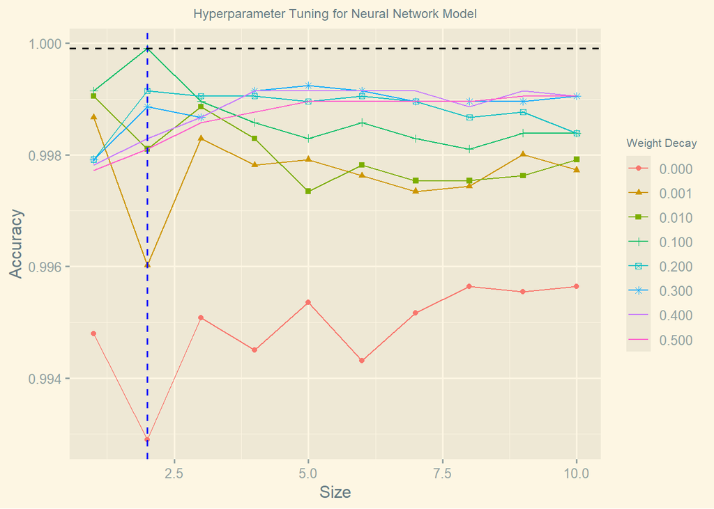

```r
# Imbalanced Data

# Get the best accuracy based on best size and decay
best_size <- fit_nnet_snv_sg_1d$bestTune$size
best_decay <- fit_nnet_snv_sg_1d$bestTune$decay
best_accuracy <- fit_nnet_snv_sg_1d$results %>%
  filter(size == best_size & decay == best_decay) %>%
  pull(Accuracy)

# Print the best accuracy
ggplot(fit_nnet_snv_sg_1d, na.rm = TRUE) +
  geom_vline(
    xintercept = best_size,
    color = "blue",
    linetype = "dashed",
    size = 0.7
  ) +
  geom_hline(
    yintercept = best_accuracy,
    color = "black",
    linetype = "dashed",
    size = 0.7
  ) +
  labs(
    title = "Hyperparameter Tuning for Neural Network Model",
    x = "Size",
    y = "Accuracy"
  ) +
  theme_solarized_2() +
  theme(
    plot.title = element_text(hjust = 0.5, size = 9),
    legend.title = element_text(size = 8)
  )
```

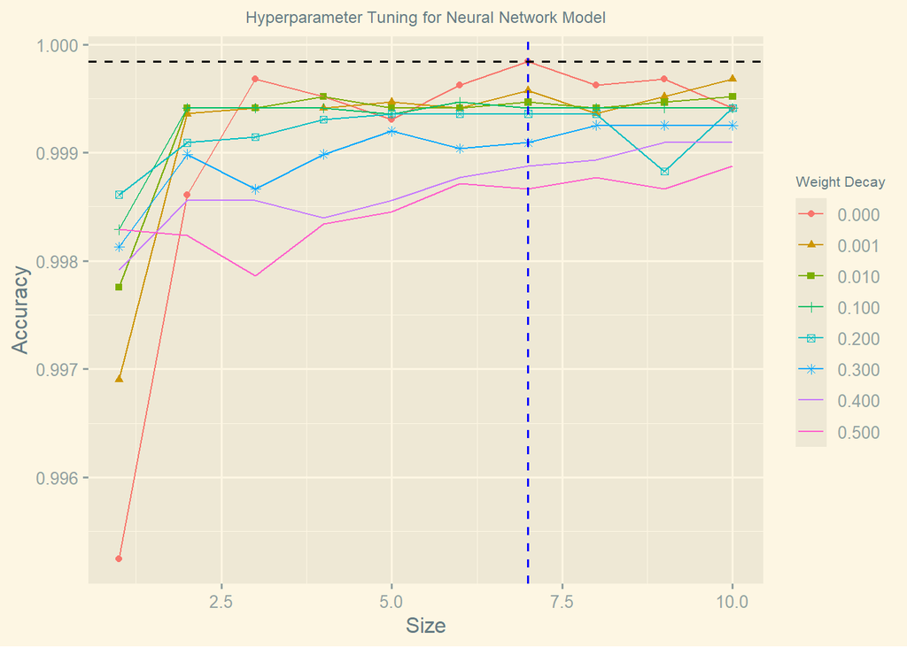

```r
# SMOTE data
# Get the best accuracy based on best size and decay
best_size <- fit_nnet_smote_snv_sg_1d$bestTune$size
best_decay <- fit_nnet_smote_snv_sg_1d$bestTune$decay
best_accuracy <- fit_nnet_smote_snv_sg_1d$results %>%
  filter(size == best_size & decay == best_decay) %>%
  pull(Accuracy)

# Print the best accuracy
ggplot(fit_nnet_smote_snv_sg_1d, na.rm = TRUE) +
  geom_vline(
    xintercept = best_size,
    color = "blue",
    linetype = "dashed",
    size = 0.7
  ) +
  geom_hline(
    yintercept = best_accuracy,
    color = "black",
    linetype = "dashed",
    size = 0.7
  ) +
  labs(
    title = "Hyperparameter Tuning for Neural Network Model",
    x = "Size",
    y = "Accuracy"
  ) +
  theme_solarized_2() +
  theme(
    plot.title = element_text(hjust = 0.5, size = 9),
    legend.title = element_text(size = 8)
  )
```

## Visualize the NNET Model Architecture

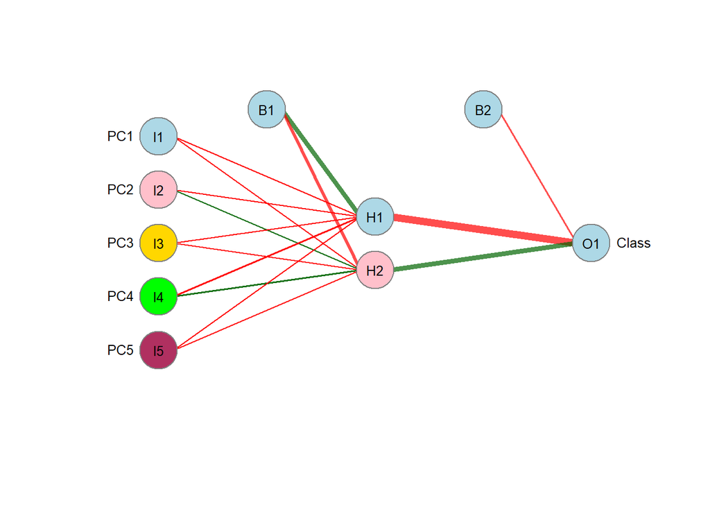

```r
# Unmodified data
plotnet(fit_nnet_snv_sg_1d$finalModel,
        y_names = 'Class',circle_col = c("lightblue", "pink",
        "gold", "green","maroon"),
        alpha = 0.7,pos_col = "darkgreen",
        neg_col = "red",cex_val = 0.8,cex_text = 0.7,bord_col = "gray50")
```

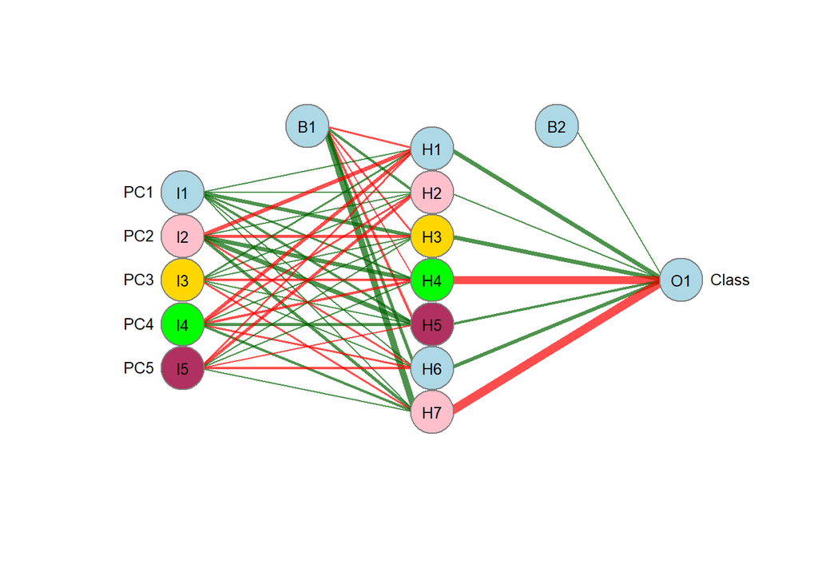

```r
#SMOTE data
plotnet(fit_nnet_smote_snv_sg_1d$finalModel,
        y_names = 'Class',circle_col = c("lightblue", "pink",
        "gold", "green","maroon"),
        alpha = 0.7,pos_col = "darkgreen",
        neg_col = "red",cex_val = 0.8,cex_text = 0.7,bord_col = "gray50")
```

## Test the model peformance on test data for unbalanced trained data

```r
# Predict on the test set
set.seed(123)
test_nnet_unmodified <- predict(fit_nnet_snv_sg_1d,
                                newdata=test_mergedPreprocessed)

# Get the confusion matrix
test_nnet_unmodified_CMtrx <- confusionMatrix(test_nnet_unmodified,
                                             test_mergedPreprocessed$binary_class)

test_nnet_unmodified_CMtrx # print the confusion matrix table
```

```
Confusion Matrix and Statistics

              Reference
Prediction     adulterated pure_arabica
  adulterated          385            1
  pure_arabica           2           26

               Accuracy : 0.9928
                 95% CI : (0.979, 0.9985)
    No Information Rate : 0.9348
    P-Value [Acc > NIR] : 3.318e-09

                  Kappa : 0.9416

 Mcnemar's Test P-Value : 1

            Sensitivity : 0.9948
            Specificity : 0.9630
         Pos Pred Value : 0.9974
         Neg Pred Value : 0.9286
             Prevalence : 0.9348
         Detection Rate : 0.9300
   Detection Prevalence : 0.9324
      Balanced Accuracy : 0.9789

       'Positive' Class : adulterated
```

```r
kable(test_nnet_unmodified_CMtrx$byClass) # Tabulate correct and incorrect classifications
```

|  | x |
| --- | --- |
| Sensitivity | 0.9948320 |
| Specificity | 0.9629630 |
| Pos Pred Value | 0.9974093 |
| Neg Pred Value | 0.9285714 |
| Precision | 0.9974093 |
| Recall | 0.9948320 |
| F1 | 0.9961190 |
| Prevalence | 0.9347826 |
| Detection Rate | 0.9299517 |
| Detection Prevalence | 0.9323671 |
| Balanced Accuracy | 0.9788975 |

```r
# View the results as knitr table
kable(test_nnet_unmodified_CMtrx$table)
```

|  | adulterated | pure_arabica |
| --- | --- | --- |
| adulterated | 385 | 1 |
| pure_arabica | 2 | 26 |

```r
# Calculate the Matthews Correlation coefficient (MCC)

# Extracting the components of the confusion matrix
cf_table_nnet <- test_nnet_unmodified_CMtrx$table
TP <- cf_table_nnet[1,1]
TN <- cf_table_nnet[2,2]
FP <- cf_table_nnet[2,1]
FN <- cf_table_nnet[1,2]

# Calculating MCC
MCC <- (TP * TN - FP * FN) / sqrt((TP + FP) * (TP + FN) * (TN + FP) * (TN + FN))

# Printing the MCC value
print(paste("The MCC value is for the model",MCC))
```

```
[1] "The MCC value is for the model 0.941753545902291"
```

## Test the model performance on test data using SMOTE trained model

```r
# Predict on the test set
set.seed(123)
test_nnet_smote <- predict(fit_nnet_smote_snv_sg_1d,
                           newdata=test_merged_smote_Preprocessed)

# Get the confusion matrix
test_nnet_smote_CMtrx <- confusionMatrix(test_nnet_smote,
                                             test_merged_smote_Preprocessed$binary_class)
test_nnet_smote_CMtrx # print the results
```

```
Confusion Matrix and Statistics

              Reference
Prediction     adulterated pure_arabica
  adulterated          383            1
  pure_arabica           4           26

               Accuracy : 0.9879
                 95% CI : (0.972, 0.9961)
    No Information Rate : 0.9348
    P-Value [Acc > NIR] : 1.471e-07

                  Kappa : 0.9058

 Mcnemar's Test P-Value : 0.3711

            Sensitivity : 0.9897
            Specificity : 0.9630
         Pos Pred Value : 0.9974
         Neg Pred Value : 0.8667
             Prevalence : 0.9348
         Detection Rate : 0.9251
   Detection Prevalence : 0.9275
      Balanced Accuracy : 0.9763

       'Positive' Class : adulterated
```

```r
kable(test_nnet_smote_CMtrx$byClass)
```

|  | x |
| --- | --- |
| Sensitivity | 0.9896641 |
| Specificity | 0.9629630 |
| Pos Pred Value | 0.9973958 |
| Neg Pred Value | 0.8666667 |
| Precision | 0.9973958 |
| Recall | 0.9896641 |
| F1 | 0.9935149 |
| Prevalence | 0.9347826 |
| Detection Rate | 0.9251208 |
| Detection Prevalence | 0.9275362 |
| Balanced Accuracy | 0.9763135 |

```r
#View the results as knitr table
kable(test_nnet_smote_CMtrx$table)
```

|  | adulterated | pure_arabica |
| --- | --- | --- |
| adulterated | 383 | 1 |
| pure_arabica | 4 | 26 |

```r
# Calculate the Matthews Correlation coefficient

# Extracting the components of the confusion matrix
cf_table_nnet_smote <- test_nnet_smote_CMtrx$table
TP <- cf_table_nnet_smote[1,1]
TN <- cf_table_nnet_smote[2,2]
FP <- cf_table_nnet_smote[2,1]
FN <- cf_table_nnet_smote[1,2]

# Calculating MCC
MCC <- (TP * TN - FP * FN) / sqrt((TP + FP) * (TP + FN) * (TN + FP) * (TN + FN))

# Printing the MCC value
print(paste("The MCC value is for the model",MCC))
```

```
[1] "The MCC value is for the model 0.907264738999711"
```

## Compare the models for unbalanced and balanced data

```r
library(knitr)
# Compare model performance
results <- resamples(list(nnet = fit_nnet_snv_sg_1d, nnet_smote = fit_nnet_smote_snv_sg_1d))

# Print summary of re-sampling results
resample_summary <- summary(results)$statistics

# Convert re-sampling statistics to a data frame
resample_df <- do.call(rbind, lapply(resample_summary, function(x) x[, "Mean", drop = FALSE]))

# Create a neat table
kable(resample_df, caption = "Model Performance Metrics")
```

Model Performance Metrics

|  | Mean |
| --- | --- |
| nnet | 0.9999057 |
| nnet_smote | 0.9998396 |
| nnet | 1.0000000 |
| nnet_smote | 1.0000000 |
| nnet | 0.9999505 |
| nnet_smote | 0.9998352 |
| nnet | 0.9544210 |
| nnet_smote | 0.4870167 |
| nnet | 0.9999502 |
| nnet_smote | 0.9998343 |
| nnet | 0.9990416 |
| nnet_smote | 0.9996788 |
| nnet | 0.0072196 |
| nnet_smote | 0.0001551 |
| nnet | 0.9983333 |
| nnet_smote | 0.9996907 |
| nnet | 1.0000000 |
| nnet_smote | 1.0000000 |
| nnet | 0.8900347 |
| nnet_smote | 0.0253980 |
| nnet | 1.0000000 |
| nnet_smote | 1.0000000 |
| nnet | 0.9999010 |
| nnet_smote | 0.9996703 |
| nnet | 0.9999010 |
| nnet_smote | 0.9996703 |
| nnet | 1.0000000 |
| nnet_smote | 1.0000000 |

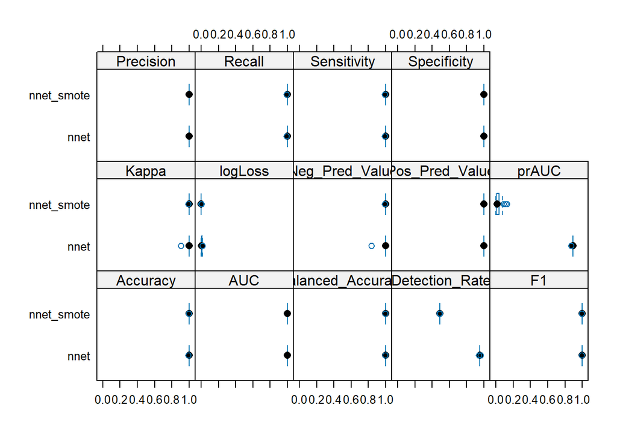

```r
# Boxplot for accuracy comparison
bwplot(results)
```

```r
# Pairwise comparisons
model_differences <- diff(results)
model_differences$statistics
```

```
$Accuracy
$Accuracy$nnet.diff.nnet_smote

    One Sample t-test

data:  x
t = 0.498, df = 99, p-value = 0.6196
alternative hypothesis: true mean is not equal to 0
95 percent confidence interval:
 -0.0001972334  0.0003294098
sample estimates:
   mean of x
6.608818e-05



$AUC
$AUC$nnet.diff.nnet_smote

    One Sample t-test

data:  x
t = NaN, df = 99, p-value = NA
alternative hypothesis: true mean is not equal to 0
95 percent confidence interval:
 NaN NaN
sample estimates:
mean of x
        0



$Balanced_Accuracy
$Balanced_Accuracy$nnet.diff.nnet_smote

    One Sample t-test

data:  x
t = 1.076, df = 99, p-value = 0.2846
alternative hypothesis: true mean is not equal to 0
```

[output cut: 166 more lines]

```


$Specificity
$Specificity$nnet.diff.nnet_smote

    One Sample t-test

data:  x
t = NaN, df = 99, p-value = NA
alternative hypothesis: true mean is not equal to 0
95 percent confidence interval:
 NaN NaN
sample estimates:
mean of x
        0
```

## Visualize the confusion matrix tables

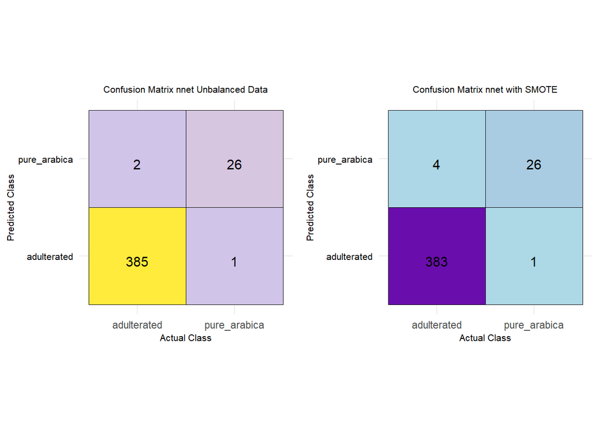

```r
p1<-ggplot(data = as.data.frame(test_nnet_unmodified_CMtrx$table), aes(x = Reference, y = Prediction)) +
  geom_tile(aes(fill = Freq), color = "black") +
  geom_text(aes(label = sprintf("%0.0f", Freq)), vjust = 1,color = "black",size = 4) +
  scale_fill_gradient(low = "#d1c4e9", high = "#ffeb3b", name = "Frequency") +
  theme_minimal() +
  labs(x = "Actual Class", y = "Predicted Class", color = 'black',title = 'Confusion Matrix nnet Unbalanced Data')+
  theme(
    legend.position =  "none",
    axis.text.y = element_text(color = "black",size = 8),
    axis.title.x  = element_text(size = 8),
    axis.title.y = element_text(size = 8),aspect.ratio = 1,
    plot.title = element_text(size = 8,hjust = 0.5))


p2<-ggplot(data = as.data.frame(test_nnet_smote_CMtrx$table), aes(x = Reference, y = Prediction)) +
  geom_tile(aes(fill = Freq), color = "black") +
  geom_text(aes(label = sprintf("%0.0f", Freq)), vjust = 1,color = "black",size = 4) +
  scale_fill_gradient(low = "lightblue", high = "#6a0dad", name = "Frequency") +
  theme_minimal() +
  labs(x = "Actual Class", y = "Predicted Class", color = 'black',title = 'Confusion Matrix nnet with SMOTE')+
  theme(
    legend.position =  "none",
    axis.text.y = element_text(color = "black",size = 8),
    axis.title.x  = element_text(size = 8),
    axis.title.y = element_text(size = 8),aspect.ratio = 1,
    plot.title = element_text(size = 8,hjust = 0.5))

grid.arrange(p1,p2, nrow =1)
```

## ROC Curve

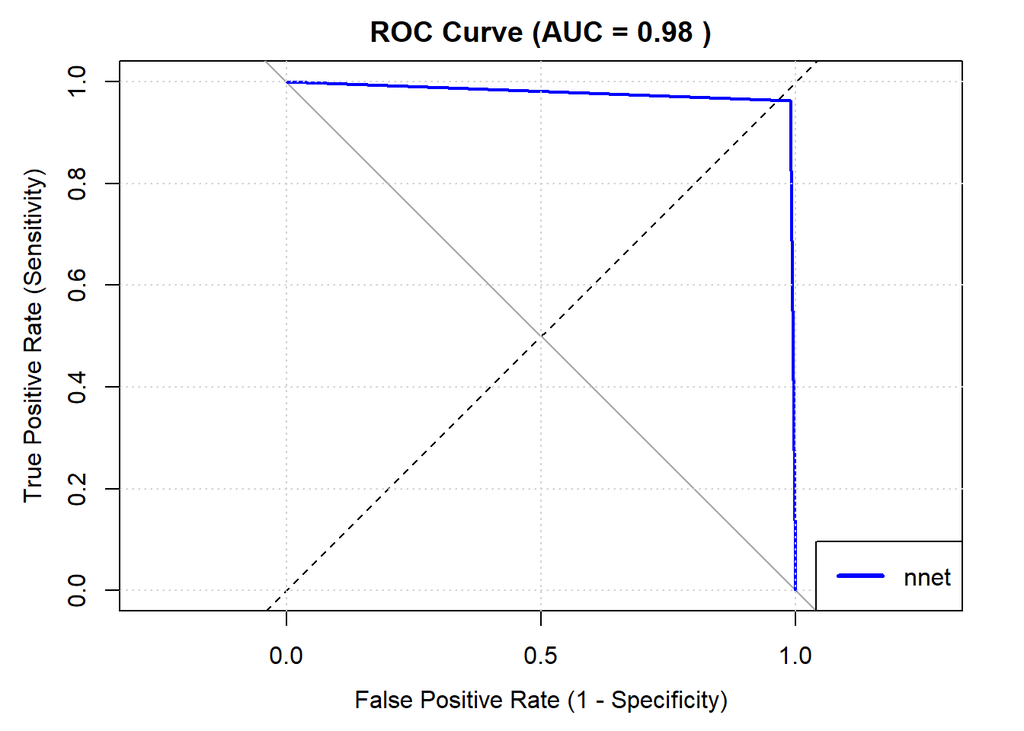

```r
# Generate the ROC curve
roc_curve <- roc(test_merged_smote_Preprocessed$binary_class,
                 as.numeric(test_nnet_smote),
                 levels = c("adulterated", "pure_arabica"),
                 positive = 'adulterated')
# Calculate the AUC
auc_value <- auc(roc_curve)

# Plot the ROC curve
plot(roc_curve, col = 'blue', lwd = 2,
     main = paste("ROC Curve (AUC =", round(auc_value, 2), ")"),
     xlab = "False Positive Rate (1 - Specificity)",
     ylab = "True Positive Rate (Sensitivity)",
     xlim = c(0, 1), ylim = c(0, 1))
abline(a = 0, b = 1, lty = 2, col = "black")
grid(nx = NULL, ny = NULL, col = "lightgray", lty = "dotted")
legend("bottomright", legend = c("nnet"), col = 'blue', lwd = 3)
```

## Conclusion

- NNET model achieve exceptional performance as observed from the ROC curve.